# Entrega P4

**Para correr este HTML**

¡ADVERTENCIA!

Es necesario instalar los paquetes “ggplot2”, “gcookbook”, “car”, “carData” Y “prettyR”

## **Análisis estadístico del acceso a una educación virtual de calidad aplicado al uso de técnicas didácticas en las universidades de Lima Metropolitana - Perú**

**Objetivo de estudio:**

El presente trabajo de investigación tiene como objetivo general realizar el análisis del nivel de eficacia de los métodos y técnicas didácticas implementadas en la enseñanza de las universidades en Lima Metropolitana - Perú.

**Importancia:**

El tema propuesto es de gran relevancia para los estudiantes y docentes puesto que, debido a la pandemia, los métodos y técnicas de enseñanza han tenido que adaptarse a la virtualidad. De esta manera, al ser una situación extraordinaria existen métodos y técnicas que no son del todo efectivos, por lo que es necesario cuantificar la calidad de estos. Esta información es indispensable para la mejora académica puesto que las universidades pueden recibir este análisis y ver que ocurre a lo largo de la pandemia y que actividades o acciones frente a la misma tuvieron un impacto positivo y cuales tuvieron un impacto negativo en los estudiantes y su aprendizaje.

**Población objetivo:**

Nuestro estudio tiene como público objetivo a profesores y estudiantes universitarios de Lima, debido a que es muy importante conocer cómo se está llevando la preparación de los estudiantes de pregrado en la virtualidad. En este caso, al analizar Lima Metropolitana podremos obtener datos de diferentes métodos de enseñanza de universidades públicas y privadas.

**Resultados esperados:**

Se espera determinar el nivel de la Educación que tienen los estudiantes universitarios en Lima desde que empezó la virtualidad, y dentro del proceso, identificar los factores determinantes y hallar los puntos más débiles.

**Proveniencia y disponibilidad de datos:**

Según lo expuesto, la forma en cómo se obtendrán los datos será por medio de encuestas online. De esta manera, al poder acceder a esta información se determina la disponibilidad de los datos estadísticos para este análisis. Además, es muy posible llegar a grandes cantidades de información mediante encuestas de donde, luego, podremos sacar analizar los datos obtenidos del forms y obtener conclusiones. Tal como se menciona en el plan de trabajo, se recolectó la información estudiantes en la ciudad de Lima por medio de encuestas virtuales. Asimismo, se utilizó un Spreadsheets para almacenar los datos obtenidos de las encuestas y estos fueron ordenados con su respectivo Variable. Para poder extraerlos, se creará un data frame del archivo con el encoding colocado en UTF-8.

**Factibilidad:**

En este estudio, la factibilidad abarca todos los datos e información necesaria para el análisis. Por el momento, se plantea realizar encuestas a los estudiantes y docentes en las universidades del espacio geográfico mencionado. Por consiguiente, se determina que este tema de estudio es viable.

**Plan de trabajo:**

A continuación se muestra una tabla que detalla las características y objetivos de cada entrega. Se detalla la fecha de publicación de la tarea, el tiempo hábil para completarla, y la fecha de entrega de cada una.

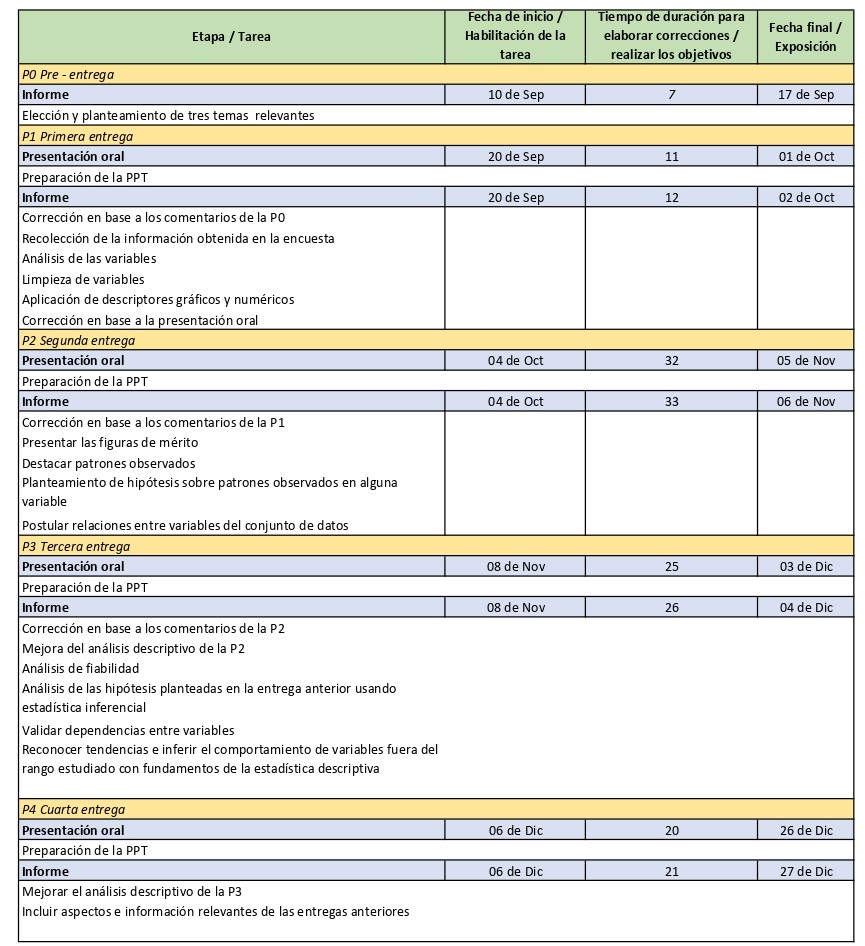

*Figura 1.Tabla de actividades del grupo 8*

Asimismo, se elaboró un diagrama de Gantt, donde se muestra de manera gráfica las fechas y días de inicio y fin donde se realizará correcciones o diferentes actividades para lograr los objetivos de la entrega correspondiente del proyecto.

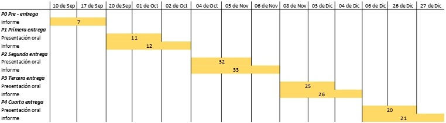

*Figura 2.Diagrama de Gantt del grupo 8*

## Primera parte

#### **1. Planteamiento de variables**

En este contexto, las variables son las siguientes:

**1.1. Variables cualitativas**

*Ordinal*

- Progreso_académico
- Dinamismo_clases

*Nominal*

- Sexo_estudiante
- Universidad
- Herramientas_docentes
- Receso_concentracion
- Universidad_enseñanza
- Cursos_competencias_digitales
- Tecnicas_optimas_docentes
- Herramientas_Didacticas_Mallas
- Mejor_tecnica_didactica

**1.2. Variables cuantitativas**

*Discreta*

- Receso
- Edad_estudiante
- Receso_ideal
- Tiempo_enseñanza
- Cantidad_cursos_didacticos
- Horas_curso_docentes
- Horas_competencias_digitales
- Dispositivos_tecnologicos
- Cantidad_tecnicas
- Cantidad_ herramientas

*Continua*

- Promedio_academico

#### **2. Tabla de variables**

**2.1. Universitario**

| Pregunta | Variable | Tipo de variable | Restricciones |
| --- | --- | --- | --- |
| ¿Cuál es tu sexo? | Sexo_estudiante | Categórica nominal | Masculino - Femenino |
| Aproximadamente, ¿cuánto es tu promedio académico actualmente? | Promedio_academico | Numérica continua | 0 - 20 |
| ¿Cuál es tu edad? | Edad_estudiante | Numérica discreta | 0 - 100 |
| ¿Cómo calificarías tu progreso académico durante la virtualidad? | Progreso_académico | Categórica ordinal | 1 - 5 |
| ¿Qué tan dinámicas crees que son tus clases virtuales? | Dinamismo_clases | Categórica ordinal | 1 - 5 |
| ¿En qué universidad estudias? | Universidad | Categórica nominal | Universidades de Lima Metropolitana |
| ¿Cuánto tiempo de receso te brinda el docente en una clase? (considerando 2 horas por clase) | Receso | Numérica discreta | 0 - 60 min |
| ¿Cuánto tiempo de receso consideras que se debería dar en cada clase? (considerando 2 horas por clase) | Receso_ideal | Numérica discreta | 0 - 60 min |
| ¿Consideras que el tiempo que te dan de receso influye en tu concentración? | Receso_concentracion | Categórica nominal | Sí - No |
| ¿Cuántos dispositivos tecnológicos usas? | Dispositivos_tecnologicos | Cuantitativa discreta | 1,2,3,4,…10 |
| ¿Cuál de estas técnicas didácticas que utilizan tus docentes complementan mejor tu aprendizaje? | Tecnicas_entendibles | Categórica nominal | Kahoots, Quizzes, Casos Grupales, Talleres, Páginas web didácticas, Discusiones en grupo, Casos Individuales, Exposición |
| ¿Cuál de las herramientas de comunicación que usan tus docentes consideras que es la mejor? | Herramientas_docentes | Categórica nominal | Correo electrónico, Canvas foro, Telegram, Whatsapp, Videoconferencias, Teams, Llamadas telefónicas, Discord |
| ¿Cuántas herramientas de comunicación usan tus docentes para tu aprendizaje? | Cantidad_herramientas | Cuantitativa discreta | 0,1,2,3,4,5,6,7,8,9,10 |
| ¿Cuántas técnicas didácticas usan tus docentes para complementar mejor tu aprendizaje? | Cantidad_tecnicas | Cuantitativa discreta | 0,1,2,3,4,5,6,7,8,9,10 |

**2.2. Docente**

[output not shown]

#### **3. Descripción de la base de datos**

#### Conexión con el archivo de datos

Se utilizó Excel para almacenar los datos obtenidos de las encuestas. Para leer un archivo de datos de extensión .csv, se creará un DataFrame “DFE”

```r
library(readr)
DFE <- read_csv("Educacion_virtual.csv")
```

Los datos fueron guardados en un **DataFrame** llamado DFE

A continuación, se muestra las variables del DataFrame DFE:

```r
names(DFE)
```

```
##  [1] "Soy"
##  [2] "¿Cuál es tu sexo?"
##  [3] "Aproximadamente, ¿Cuánto es tu promedio académico actualmente?."
##  [4] "¿Cuál es tu edad?"
##  [5] "¿Cómo calificarías a tu progreso académico durante la virtualidad?"
##  [6] "¿Qué tan dinámicas crees que son tus clases virtuales?"
##  [7] "¿En qué universidad estudias?"
##  [8] "¿Cuánto tiempo de receso te brinda el docente en una clase? (considerando 2 horas por clase)"
##  [9] "¿Cuánto tiempo de receso consideras que se debería dar en cada clase? (considerando 2 horas por clase)"
## [10] "¿Consideras que el tiempo que te dan de receso influye positivamente en tu concentración?"
## [11] "¿Cuántos dispositivos tecnológicos usas?"
## [12] "¿Cuánto tiempo tienes enseñando a nivel universitario?"
## [13] "¿Cuántos cursos llevaste relacionado con técnicas didácticas de aprendizaje?"
## [14] "¿Has llevado algún curso de competencias digitales?"
## [15] "¿En qué universidad enseñas?"
## [16] "¿Cuál de las herramientas de comunicación que usan tus docentes consideras que es la mejor?"
## [17] "¿Cuántas herramientas de comunicación usan tus docentes para tu aprendizaje?"
## [18] "¿Cuántas horas llevaste en este tipo de cursos de competencias digitales?  ( \"0\" si en la respuesta anterior marcaste No)"
## [19] "¿Cuál de estas técnicas didácticas que utilizan tus docentes complementan mejor tu aprendizaje?"
## [20] "¿Cuántas técnicas didácticas usan tus docentes para complementar mejor tu aprendizaje?"
## [21] "¿Consideras que las mallas curriculares de los cursos fomentan el uso de herramientas didácticas?"
## [22] "¿Cuántas horas académicas en total llevaste o estás llevando en cursos relacionados a técnicas didácticas de aprendizaje ?"
## [23] "¿Cuál de las técnicas didácticas que empleas en clase consideras que refuerza mejor la enseñanza del estudiante universitario?"
```

Procedemos a cambiar el nombre de las variables para acceder a los datos de una manera más práctica:

```r
library(dplyr)
DFE %>% rename(Sexo_estudiante = `¿Cuál es tu sexo?`, Promedio_academico = `Aproximadamente, ¿Cuánto es tu promedio académico actualmente?.`, Edad_estudiante = `¿Cuál es tu edad?`, Progreso_academico = `¿Cómo calificarías a tu progreso académico durante la virtualidad?`, Dinamismo_clases = `¿Qué tan dinámicas crees que son tus clases virtuales?`, Universidad = `¿En qué universidad estudias?`, Receso = `¿Cuánto tiempo de receso te brinda el docente en una clase? (considerando 2 horas por clase)`,  Receso_ideal = `¿Cuánto tiempo de receso consideras que se debería dar en cada clase? (considerando 2 horas por clase)`, Receso_concentracion = `¿Consideras que el tiempo que te dan de receso influye positivamente en tu concentración?`, Dispositivos_tecnologicos = `¿Cuántos dispositivos tecnológicos usas?`, Tiempo_enseñanza = `¿Cuánto tiempo tienes enseñando a nivel universitario?`, Cantidad_cursos_didacticos = `¿Cuántos cursos llevaste relacionado con técnicas didácticas de aprendizaje?`, Universidad_enseñanza = `¿En qué universidad enseñas?`, Herramientas_docentes = `¿Cuál de las herramientas de comunicación que usan tus docentes consideras que es la mejor?`, Horas_competencias_digitales = `¿Cuántas horas llevaste en este tipo de cursos de competencias digitales?  ( "0" si en la respuesta anterior marcaste No)`, Herramientas_didacticas_malla= `¿Consideras que las mallas curriculares de los cursos fomentan el uso de herramientas didácticas?`, Horas_curso_docente = `¿Cuántas horas académicas en total llevaste o estás llevando en cursos relacionados a técnicas didácticas de aprendizaje ?`, Tecnicas_optimas_docentes = `¿Cuál de las técnicas didácticas que empleas en clase consideras que refuerza mejor la enseñanza del estudiante universitario?`, Cursos_competencias_digitales = `¿Has llevado algún curso de competencias digitales?`, Cantidad_herramientas= `¿Cuántas herramientas de comunicación usan tus docentes para tu aprendizaje?` , Cantidad_tecnicas= `¿Cuántas técnicas didácticas usan tus docentes para complementar mejor tu aprendizaje?`, Mejor_tecnica_didactica= `¿Cuál de estas técnicas didácticas que utilizan tus docentes complementan mejor tu aprendizaje?` ) -> DFV
```

De esta manera, las variables serían:

```r
names(DFV)
```

```
##  [1] "Soy"                           "Sexo_estudiante"
##  [3] "Promedio_academico"            "Edad_estudiante"
##  [5] "Progreso_academico"            "Dinamismo_clases"
##  [7] "Universidad"                   "Receso"
##  [9] "Receso_ideal"                  "Receso_concentracion"
## [11] "Dispositivos_tecnologicos"     "Tiempo_enseñanza"
## [13] "Cantidad_cursos_didacticos"    "Cursos_competencias_digitales"
## [15] "Universidad_enseñanza"         "Herramientas_docentes"
## [17] "Cantidad_herramientas"         "Horas_competencias_digitales"
## [19] "Mejor_tecnica_didactica"       "Cantidad_tecnicas"
## [21] "Herramientas_didacticas_malla" "Horas_curso_docente"
## [23] "Tecnicas_optimas_docentes"
```

Para que R nos de un resumen estadístico de las variables del DataFrame usamos la función **summary**. Nos muestra para cada variable el valor mínimo, el primer y tercer cuartil, la mediana, la media y el máximo valor.

```r
summary(DFV)
```

```
##      Soy            Sexo_estudiante    Promedio_academico Edad_estudiante
##  Length:159         Length:159         Min.   : 9.00      Min.   :17.00
##  Class :character   Class :character   1st Qu.:13.00      1st Qu.:18.00
##  Mode  :character   Mode  :character   Median :15.00      Median :18.00
##                                        Mean   :14.32      Mean   :18.89
##                                        3rd Qu.:15.00      3rd Qu.:20.00
##                                        Max.   :19.00      Max.   :27.00
##                                        NA's   :19         NA's   :19
##  Progreso_academico Dinamismo_clases Universidad            Receso
##  Min.   :1.00       Min.   :1.000    Length:159         Min.   : 0.000
##  1st Qu.:3.00       1st Qu.:2.000    Class :character   1st Qu.:10.000
##  Median :3.00       Median :3.000    Mode  :character   Median :10.000
##  Mean   :3.35       Mean   :3.043                       Mean   : 9.536
##  3rd Qu.:4.00       3rd Qu.:4.000                       3rd Qu.:10.000
##  Max.   :5.00       Max.   :5.000                       Max.   :20.000
##  NA's   :19         NA's   :19                          NA's   :19
##   Receso_ideal   Receso_concentracion Dispositivos_tecnologicos
##  Min.   : 5.00   Length:159           Min.   :1.000
##  1st Qu.:10.00   Class :character     1st Qu.:2.000
##  Median :15.00   Mode  :character     Median :2.000
##  Mean   :13.51                        Mean   :2.186
##  3rd Qu.:15.00                        3rd Qu.:2.000
##  Max.   :30.00                        Max.   :5.000
##  NA's   :19                           NA's   :19
##  Tiempo_enseñanza Cantidad_cursos_didacticos Cursos_competencias_digitales
##  Min.   : 3.0     Min.   : 0.000             Length:159
##  1st Qu.: 9.5     1st Qu.: 4.000             Class :character
##  Median :15.0     Median : 6.000             Mode  :character
##  Mean   :13.0     Mean   : 5.526
##  3rd Qu.:17.0     3rd Qu.: 7.000
##  Max.   :20.0     Max.   :10.000
##  NA's   :140      NA's   :140
##  Universidad_enseñanza Herramientas_docentes Cantidad_herramientas
##  Length:159            Length:159            Min.   :2.000
##  Class :character      Class :character      1st Qu.:3.000
##  Mode  :character      Mode  :character      Median :3.000
##                                              Mean   :3.529
##                                              3rd Qu.:4.000
##                                              Max.   :5.000
##                                              NA's   :19
##  Horas_competencias_digitales Mejor_tecnica_didactica Cantidad_tecnicas
##  Min.   :100.0                Length:159              Min.   :1.0
##  1st Qu.:120.0                Class :character        1st Qu.:3.0
##  Median :180.0                Mode  :character        Median :4.0
##  Mean   :173.2                                        Mean   :3.8
##  3rd Qu.:190.0                                        3rd Qu.:4.0
##  Max.   :360.0                                        Max.   :5.0
##  NA's   :140                                          NA's   :19
##  Herramientas_didacticas_malla Horas_curso_docente Tecnicas_optimas_docentes
##  Length:159                    Min.   :  0.00      Length:159
##  Class :character              1st Qu.: 20.00      Class :character
##  Mode  :character              Median : 40.00      Mode  :character
##                                Mean   : 53.95
##                                3rd Qu.: 90.00
##                                Max.   :120.00
##                                NA's   :140
```

Tabla de frecuencia de datos faltantes (NA’s) y datos no faltantes.

```r
table(is.na(DFV))
```

```
##
## FALSE  TRUE
##  2291  1366
```

Hay 2291 datos no faltantes y 1366 datos faltantes.

#### **4. Limpieza de datos**

#### Procedemos con la limpieza de datos de nuestra base de datos

4.1. Realizamos una limpieza a la variable “Universidad”:

```r
table(DFV$Universidad)
```

```
##
##                                otros                                 PUCP
##                                   16                                    2
##                                  UNI                  Universidad de Lima
##                                    1                                    9
##             Universidad del Pacífico Universidad Peruana Cayetano Heredia
##                                    7                                    2
##                                UNMSM                                  UPC
##                                    2                                    5
##                                 UTEC                                  UTP
##                                   88                                    8
```

```r
DFV$Universidad[DFV$Universidad == "otros"] <- "Otros"
DFV$Universidad[DFV$Universidad == "Universidad de Lima"] <- "UL"
DFV$Universidad[DFV$Universidad == "Universidad del Pacífico"] <- "UP"
DFV$Universidad[DFV$Universidad == "Universidad Peruana Cayetano Heredia"] <- "UPCH"
```

Verificamos que se haya realizado la modificación:

```r
table(DFV$Universidad)
```

```
##
## Otros  PUCP    UL   UNI UNMSM    UP   UPC  UPCH  UTEC   UTP
##    16     2     9     1     2     7     5     2    88     8
```

Efectivamente, se realizó correctamente la modificación.

4.2. Cambiamos el nombre de las herramientas de comunicación

```r
DFV$Herramientas_docentes[DFV$Herramientas_docentes == "Correo electrónico"] <- "Correo"
DFV$Herramientas_docentes[DFV$Herramientas_docentes == "Llamadas telefónicas"] <- "Call"
DFV$Herramientas_docentes[DFV$Herramientas_docentes == "Teams"] <- "Teams"
DFV$Herramientas_docentes[DFV$Herramientas_docentes == "Telegram"] <- "Teleg"
DFV$Herramientas_docentes[DFV$Herramientas_docentes == "Canvas foro"] <- "Canvas"
DFV$Herramientas_docentes[DFV$Herramientas_docentes == "Discord"] <- "Discord"
DFV$Herramientas_docentes[DFV$Herramientas_docentes == "Videoconferencias"] <- "Video"
DFV$Herramientas_docentes[DFV$Herramientas_docentes == "Whatsapp"] <- "Wsp"
```

```r
table(DFV$Herramientas_docentes)
```

```
##
##    Call  Canvas  Correo Discord   Teams   Teleg   Video     Wsp
##       1      18      33      24       4      19      17      24
```

4.3. Cambiamos el nombre de las técnicas didácticas

```r
DFV$Mejor_tecnica_didactica[DFV$Mejor_tecnica_didactica == "Casos Grupales"] <- "Casos"
DFV$Mejor_tecnica_didactica[DFV$Mejor_tecnica_didactica == "Casos Individuales"] <- "Individual"
DFV$Mejor_tecnica_didactica[DFV$Mejor_tecnica_didactica == "Discusiones en grupo"] <- "Grupo"
DFV$Mejor_tecnica_didactica[DFV$Mejor_tecnica_didactica == "Exposición"] <- "Exposición"
DFV$Mejor_tecnica_didactica[DFV$Mejor_tecnica_didactica == "Kahoots"] <- "Kahoots"
DFV$Mejor_tecnica_didactica[DFV$Mejor_tecnica_didactica == "Páginas web didácticas"] <- "Web"
```

```r
table(DFV$Mejor_tecnica_didactica)
```

```
##
##      Casos Exposición      Grupo Individual    Kahoots    Quizzes   Talleres
##         37         14         21         13         20         18          7
##        Web
##         10
```

4.4. Cambiamos la variable Universidad_enseñanza

```r
DFV$Universidad_enseñanza[DFV$Universidad_enseñanza == "Universidad de Lima"] <- "UL"
DFV$Universidad_enseñanza[DFV$Universidad_enseñanza == "Universidad del Pacífico"] <- "UP"
```

```r
table(DFV$Universidad_enseñanza)
```

```
##
##  PUCP    UL   UNI UNMSM    UP  UPCH  USIL  UTEC
##     1     4     1     1     4     1     1     6
```

#### **5. Desarrollo de preguntas**

**Dato:** Para los intervalos de confianza hallados en solo las variables de interés, hemos utilizado un *nivel de confianza del 95%* y un *nivel de significancia del 5%*.

**5.1. Sexo_estudiante y Sexo_docente**

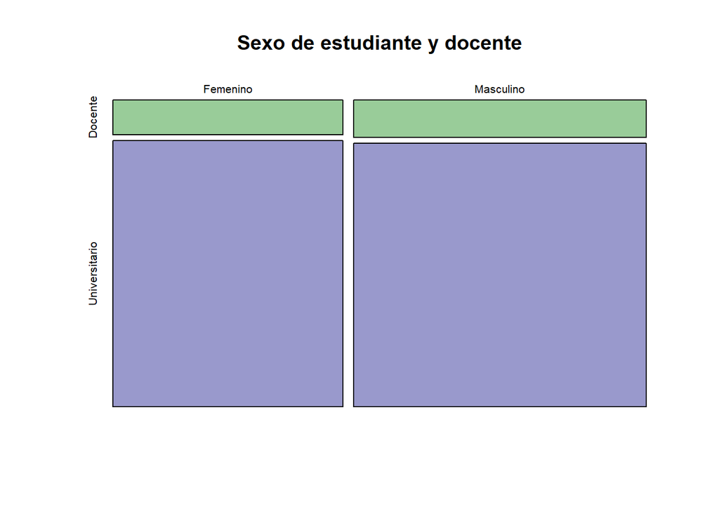

```r
mosaicplot(table(DFV$Sexo_estudiante, DFV$Soy), main="Sexo de estudiante y docente", col=c("#99cc99","#9999cc"))
```

**5.1. Análisis del gráfico:**

En el mosaico “Sexo de estudiante y docente”. De los universitarios (incluye hombres y mujeres), se puede apreciar que existe mas observaciones masculinas que femeninas. Lo mismo sucede con los docentes (incluye hombres y mujeres), la proporción de hombres es un poco mayor que la de mujeres. Diciendo así que tenemos una muestra concentrada en el sexo masculino.

*Bloque para Universitarios*

**5.2. ¿En qué universidad estudias?**

*5.2.1. Descriptor numérico:*

```r
library(prettyR)
Mode(DFV$Universidad)  ## utilizamos la función "Mode" del paquete "prettyR", para calcular la moda de la variable (unimodal)
```

```
## [1] "UTEC"
```

*5.2.2. Descriptor gráfico:*

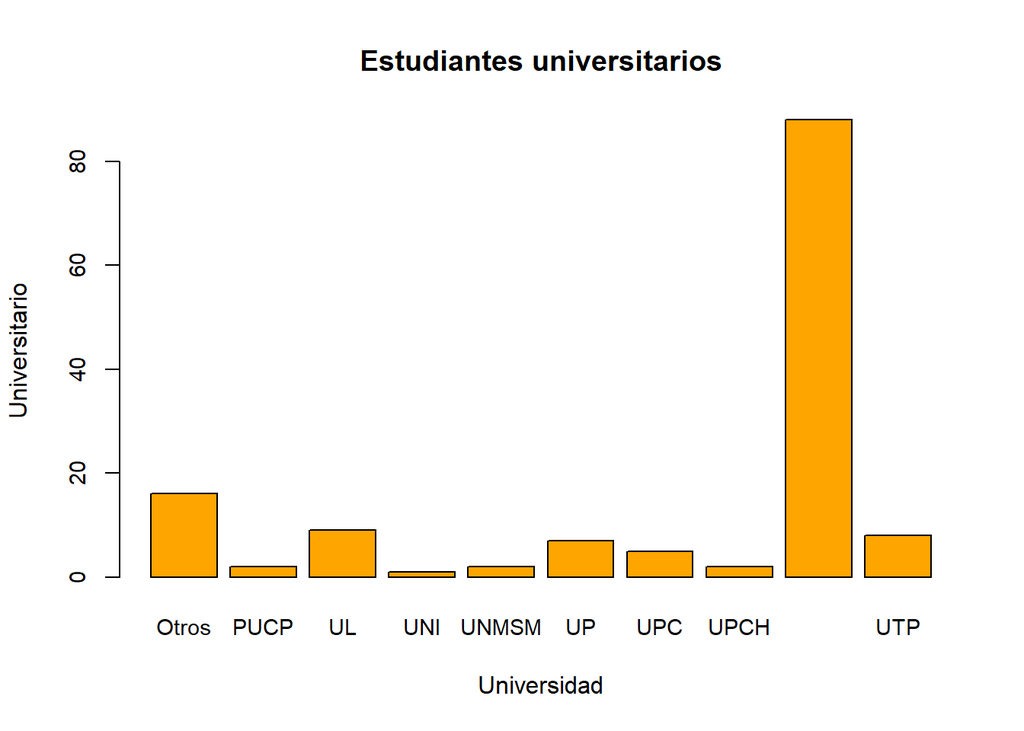

```r
barplot(table(DFV$Universidad), main="Estudiantes universitarios", horiz=FALSE, col="orange", xlab= "Universidad", ylab= "Universitario", cex.axis=0.9, cex.names=0.9)
```

*5.2.3. Análisis de la gráfica:*

El total de estudiantes universitarios encuestados es de **140**. A partir de la gráfica “Estudiantes universitarios” se puede observar que la universidad con mayor cantidad de encuestados es **UTEC** y la universidad con menor cantidad de encuestados fue la UNI con un 1%. Esto nos quieres decir, que la muestra analizada se concentra en los estudiantes de la universidad **UTEC** con una mayor frecuencia de observaciones.

*5.2.4. Intervalo de confianza:*

```
## Universidad:  UTEC
##      [,1]      [,2]
## [1,] "lim_inf" "0.59"
## [2,] "lim_sup" "0.74"
## Universidad:  UTP
##      [,1]      [,2]
## [1,] "lim_inf" "0.12"
## [2,] "lim_sup" "0.24"
## Universidad:  UPCH
##      [,1]      [,2]
## [1,] "lim_inf" "0.09"
## [2,] "lim_sup" "0.2"
## Universidad:  UPC
##      [,1]      [,2]
## [1,] "lim_inf" "0.1"
## [2,] "lim_sup" "0.22"
## Universidad:  PUCP
##      [,1]      [,2]
## [1,] "lim_inf" "0.09"
## [2,] "lim_sup" "0.2"
## Universidad:  UP
##      [,1]      [,2]
## [1,] "lim_inf" "0.11"
## [2,] "lim_sup" "0.23"
## Universidad:  UL
##      [,1]      [,2]
## [1,] "lim_inf" "0.12"
## [2,] "lim_sup" "0.25"
## Universidad:  Otros
##      [,1]      [,2]
## [1,] "lim_inf" "0.16"
## [2,] "lim_sup" "0.29"
## Universidad:  UNI
##      [,1]      [,2]
## [1,] "lim_inf" "0.08"
## [2,] "lim_sup" "0.19"
## Universidad:  UNMSM
##      [,1]      [,2]
## [1,] "lim_inf" "0.09"
## [2,] "lim_sup" "0.2"
```

**5.3. ¿Cuál es el promedio de las notas de los estudiantes?**

*5.3.1. Descriptor numérico:*

```r
round(mean(DFV$Promedio_academico, na.rm = T), digits=2) # Promedio
```

```
## [1] 14.32
```

```r
library(prettyR)
Mode(DFV$Promedio_academico)    ## utilizamos la función "Mode" del paquete "prettyR", para calcular la moda de la variable (unimodal)
```

```
## [1] "15"
```

```r
median(DFV$Promedio_academico, na.rm = T)  # Mediana
```

```
## [1] 15
```

```r
round(var(DFV$Promedio_academico, na.rm=T), digits = 2) # Varianza
```

```
## [1] 3.43
```

```r
round(sd(DFV$Promedio_academico, na.rm=T), 2) # Desviación estándar
```

```
## [1] 1.85
```

```r
round(sd(DFV$Promedio_academico, na.rm=T), 2) -> d1
round(mean(DFV$Promedio_academico, na.rm=T), 2) -> p1
round(d1/p1, 2)  # Coeficiente de variación
```

```
## [1] 0.13
```

*5.3.2. Descriptor gráfico:*

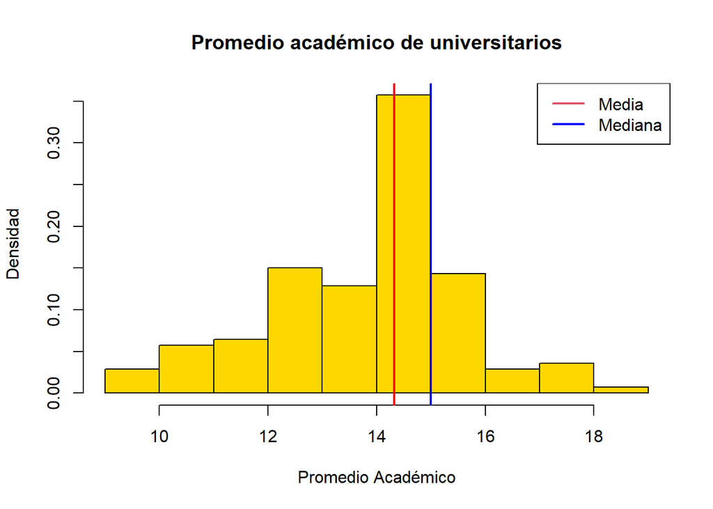

```r
hist(DFV$Promedio_academico, main="Promedio académico de universitarios", col="gold", border="black", xlab="Promedio Académico",ylab="Densidad", prob=T)
abline(v=mean(DFV$Promedio_academico, na.rm=T),col="red",lwd=2)
abline(v=median(DFV$Promedio_academico, na.rm=T),col="blue",lwd=2)
legend(x = "topright", legend = c("Media","Mediana"), lty= c(1,1), col=c(2,"blue"), lwd=2) # topright es la ubicación de la leyenda
```

*5.3.3. Análisis de la gráfica:*

El histograma “Promedio académico de universitarios presenta una distribución no simétrica hacia la izquierda, siendo la media ligeramente menor que la mediana con valores 14, 32 y 15 respectivamente. Asi como también que la moda y la mediana tiene el mismo valor en el estudio de esta variable.

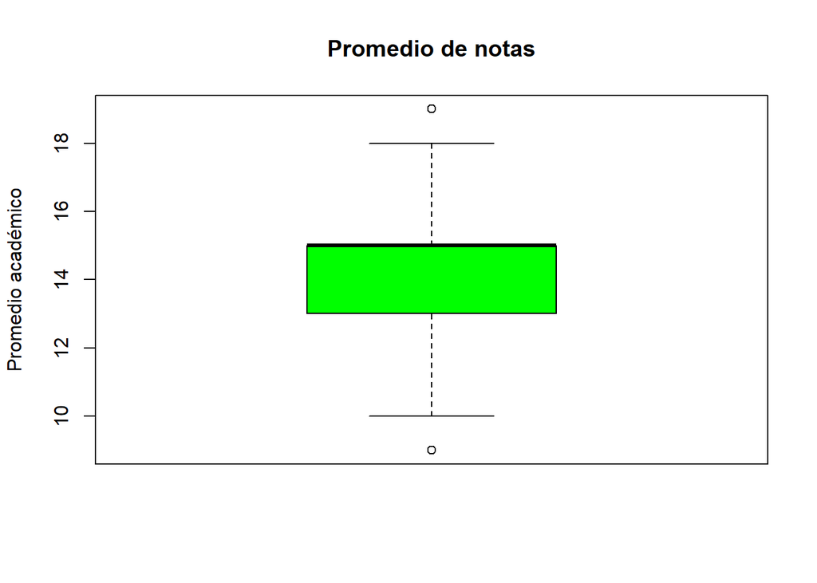

```r
boxplot(DFV$Promedio_academico, main="Promedio de notas", ylab="Promedio académico", col="green")
```

*5.3.4. Análisis de la gráfica:*

*5.3.5. Intervalo de confianza:*

```
##      [,1]      [,2]
## [1,] "lim_inf" "14.01"
## [2,] "lim_sup" "14.63"
```

*5.3.6. Análisis del intervalo de confianza:*

En cuanto el promedio académico, tenemos que sus intervalos de confianza para la media cuyos extremos, inferior y superior, son 14.01 y 14.63 con un nivel de confianza del 95% y un nivel significativo del 5%. El margen de error es de 0.62, lo cual se obtuvo restando los limites obtenidos. Finalmente calculamos los valores críticos tomando la mitad del nivel de significativo y el grado de libertad como parámetros.

**5.4. ¿Qué tan dinámicas crees que son tus clases?**

*5.4.1. Descriptor numérico:*

```r
library(prettyR)
Mode(DFV$Dinamismo_clases)    ## utilizamos la función "Mode" del paquete "prettyR", para calcular la moda de la variable (unimodal)
```

```
## [1] "3"
```

*5.4.2. Descriptor gráfico:*

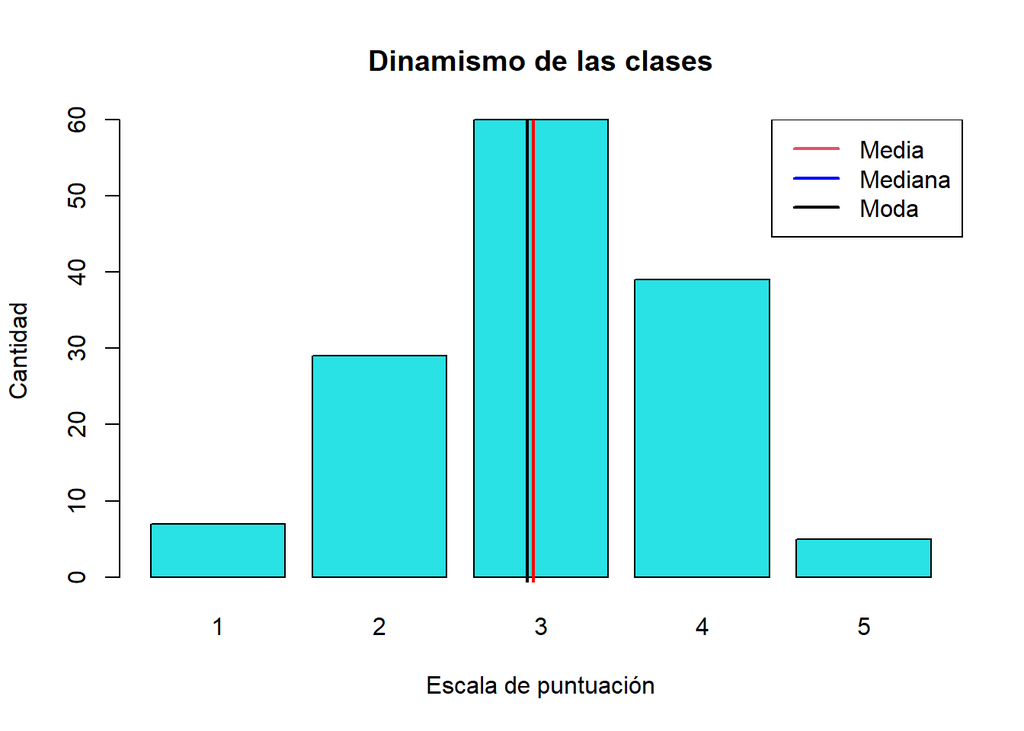

```r
barplot(table(DFV$Dinamismo_clases), main= "Dinamismo de las clases", col=c(5), xlab="Escala de puntuación", ylab="Cantidad")
abline(v=mean(DFV$Dinamismo_clases, na.rm=T),col="red",lwd=2)
abline(v=median(DFV$Dinamismo_clases, na.rm=T),col="blue",lwd=2)
abline(v=Mode(DFV$Dinamismo_clases, na.rm=T),col="black",lwd=2)
legend(x = "topright", legend = c("Media","Mediana", "Moda"), lty= c(1,1,1), col=c(2,"blue", "black"), lwd=2) # topright es la ubicación de la leyenda
```

*5.4.3. Análisis de la gráfica:*

Podemos observar que no existe mucha dispersión en los datos. Puesto que, tanto la moda, la media y la mediana tienen aproximadamente el mismo valor. Siendo “3” el valor con mayor frecuencia que alude al dinamismo de las clases de los estudiantes universitarios encuestados

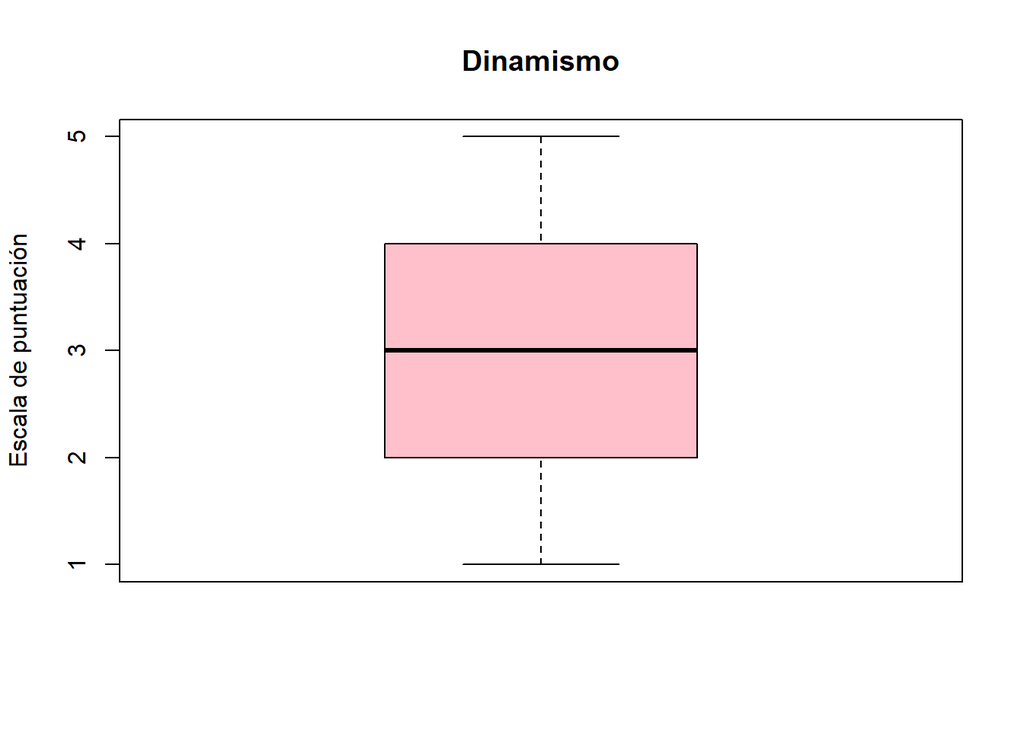

```r
boxplot(DFV$Dinamismo_clases, main= "Dinamismo", col="pink", ylab="Escala de puntuación")
```

*5.4.4. Análisis de la gráfica:*

De igual manera, en el diagrama de cajas un 50% de las observaciones en la muestra estadística es mayor o igual a 3. Del mismo modo, se puede observar que como la mediana esta cerca del centro de la caja, la distribución es mas o menos simétrica, dando así intervalos de igual tamaño para contener los dos cuartos centrales de los datos. A su vez el 50% de los datos se encuentra entre **2** y **4**, lo cual nos permite consolidar nuestra afirmación acerca de que para la mayoría de los estudiantes encuestados de las distintas universidades de Lima Metropolitana - Perú consideran que las clases brindadas por los docentes no son tan dinámicas, trayendo consigo la poca concentración y ausencia de entusiasmo durante las clases brindadas.

*5.4.5. Intervalo de confianza:*

```
##      [,1]      [,2]
## [1,] "lim_inf" "2.89"
## [2,] "lim_sup" "3.2"
```

**5.5. ¿Cuál de las herramientas de comunicación que usan tus docentes consideras que es la mejor?**

*5.5.1. Descriptor numérico*

```r
library(prettyR)
Mode(DFV$Herramientas_docentes)    ## utilizamos la función "Mode" del paquete "prettyR", para calcular la moda de la variable (unimodal)
```

```
## [1] "Correo"
```

```r
table(DFV$Herramientas_docentes)
```

```
##
##    Call  Canvas  Correo Discord   Teams   Teleg   Video     Wsp
##       1      18      33      24       4      19      17      24
```

*5.5.2. Descriptor gráfico*

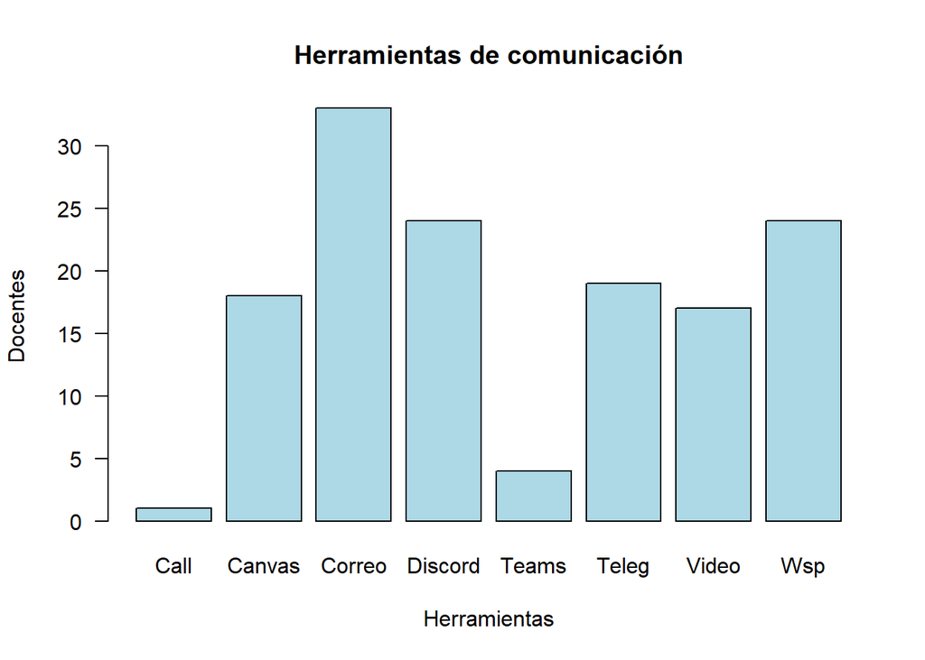

```r
barplot(table(DFV$Herramientas_docentes), main="Herramientas de comunicación", horiz=FALSE, col="lightblue", xlab= "Herramientas", ylab= "Docentes", las=1)
```

*5.5.3. Análisis de la gráfica:*

En el gráfico de barras, se puede observar que la herramienta de comunicación con una mayor frecuencia de 33 observaciones es el correo electrónico. No obstante, consideran a las llamadas telefónicas como la herramienta menos factible para comunicarse con sus docentes dado que tiene solo una valoración. Estas cifras nos señalan que las herramientas de gestión más usadas para la mejora del aprendizaje así como también el papel significativo que tienen en los estudiantes, ya que, facilitan el intercambio de información, colaboración y comunicación entre los estudiantes y docentes, más aún en una época donde las clases se están llevando en virtualidad para lo cuál es de suma importancia el buen uso de las herramientas de comunicación.

**5.6. ¿Cuáles de estas técnicas didácticas que utilizan tus docentes complementan mejor tu aprendizaje?**

*5.6.1. Descriptor numérico*

```r
library(prettyR)
Mode(DFV$Mejor_tecnica_didactica)  ## utilizamos la función "Mode" del paquete "prettyR", para calcular la moda de la variable (unimodal)
```

```
## [1] "Casos"
```

```r
table(DFV$Mejor_tecnica_didactica)
```

```
##
##      Casos Exposición      Grupo Individual    Kahoots    Quizzes   Talleres
##         37         14         21         13         20         18          7
##        Web
##         10
```

*5.6.2. Descriptor gráfico*

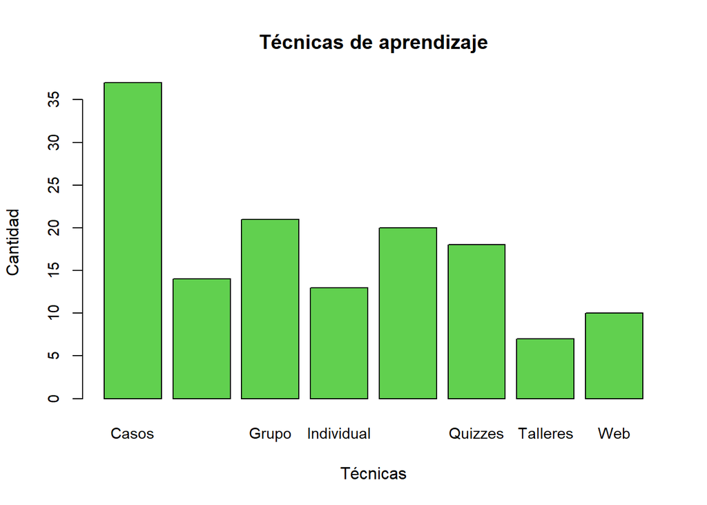

```r
barplot(table(DFV$Mejor_tecnica_didactica), col=c(3), main="Técnicas de aprendizaje", xlab="Técnicas", ylab="Cantidad", cex.axis = 0.9, cex.names = 0.9)
```

*5.6.3. Análisis de la gráfica:*

Evaluando el gráfico de barras “Técnicas de aprendizaje” se puede afirmar que tanto los **casos grupales**, **las discusiones en grupo**, **Kahoots** y **Quizzes** con **37**, **21**, **20** y **18** observaciones respectivamente se consolidan como las mejores técnicas empleadas por los docentes para facilitar el procesamiento profundo de las lecciones académicas. Por el contrario, la técnica de aprendizaje que alude a una valoración mínima de 7 son los **talleres**. Este resultado es muy importante para nuestro análisis, pues, nos permite conocer la interacción didáctica que utiliza el docente de forma intencional como instrumento para lograr que sus estudiantes reciban una enseñanza de calidad donde el aprendizaje sea significativo en este nuevo entorno digital.

**5.7. ¿Consideras que el tiempo que te dan de receso influye positivamente en tu concentración?**

*5.7.1. Descriptor numérico*

```r
Mode(DFV$Receso_concentracion)
```

```
## [1] "Sí"
```

*5.7.2. Descriptor gráfico*

```r
table(DFV$Receso_concentracion)
```

```
##
##  No  Sí
##  40 100
```

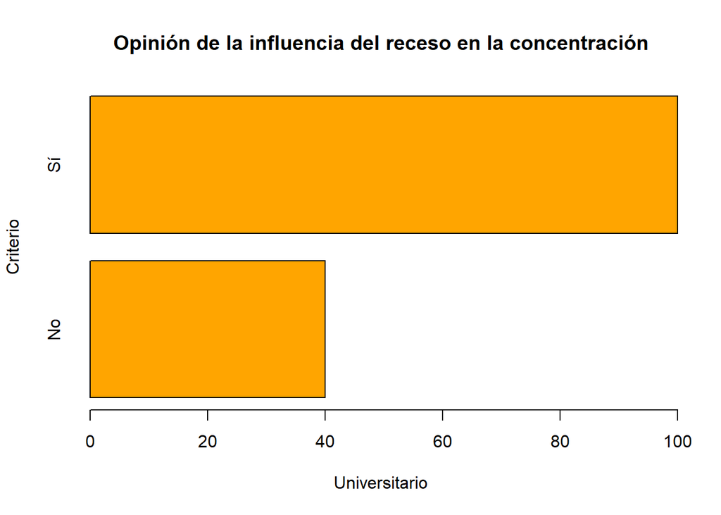

```r
barplot(table(DFV$Receso_concentracion), main="Opinión de la influencia del receso en la concentración", horiz=TRUE, col="orange", xlab="Universitario", ylab="Criterio")
```

*5.7.3. Análisis de la gráfica:*

Observando la gráfica, podemos decir que la mayoría de estudiantes universitarios con una cantidad de 100 observaciones opinan que el tiempo de receso dado por sus docentes en una clase de 2 horas repercute en el nivel de concentración que se tenga durante la clase en línea. el mismo modo, cabe resaltar que una minoría de 40 estudiantes consideran que el tiempo no influye directamente en la concentración que se ha de tener durante las clases. Estas cifras nos permite a nosotros tener un estudio completo donde se relaciona el tiempo de receso con la concentración aludiendo al procesamiento de la información brindada en la clase.

*A continuación, se mostrará los resultados acerca de los tiempos de receso para los estudiantes universitarios:*

**5.8. ¿Cuánto tiempo de receso te brinda el docente en una clase? (considerando 2 horas por clase)**

*5.8.1. Descriptor numérico*

```r
round(mean(DFV$Receso, na.rm=T), digits = 2)  # Promedio
```

```
## [1] 9.54
```

```r
Mode(DFV$Receso)
```

```
## [1] "10"
```

```r
median(DFV$Receso, na.rm = T)  # Mediana
```

```
## [1] 10
```

```r
round(var(DFV$Receso, na.rm=T), digits = 2) # Varianza
```

```
## [1] 14.71
```

```r
round(sd(DFV$Receso, na.rm=T), 2) # Desviación estándar
```

```
## [1] 3.84
```

```r
round(sd(DFV$Receso, na.rm=T), 2) -> d1
round(mean(DFV$Receso, na.rm=T), 2) -> p1
round(d1/p1, 2)  # Coeficiente de variación
```

```
## [1] 0.4
```

*5.8.2. Descriptor gráfico*

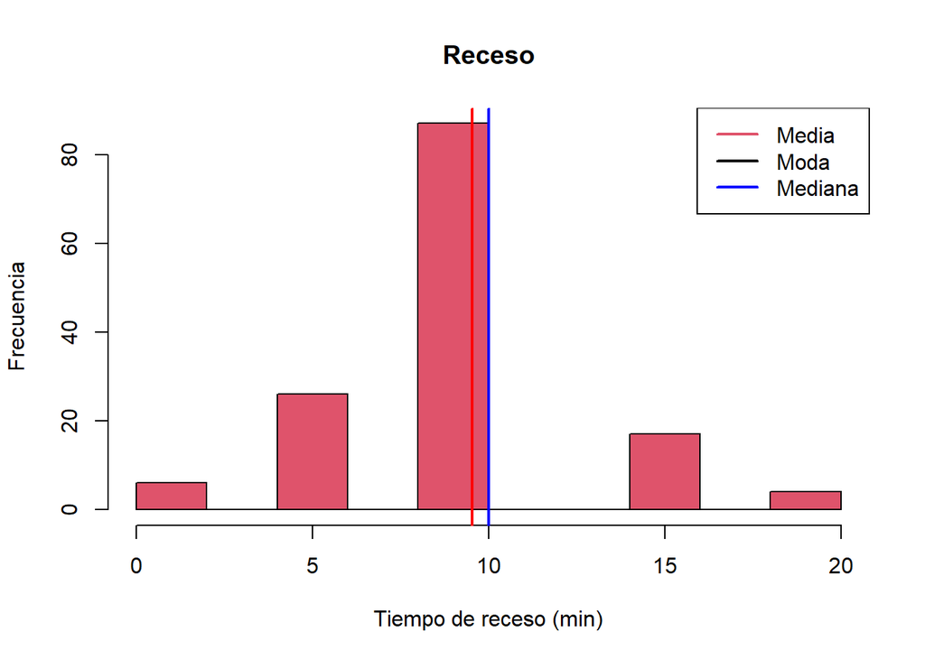

```r
hist(DFV$Receso, main= "Receso", xlab="Tiempo de receso (min)", ylab="Frecuencia", col=c(2))
abline(v=mean(DFV$Receso, na.rm=T),col="red",lwd=2)
abline(v=Mode(DFV$Receso, na.rm=T),col="9",lwd=2)
abline(v=median(DFV$Receso, na.rm=T),col="blue",lwd=2)
legend(x = "topright", legend = c("Media","Moda", "Mediana"), lty= c(1,1,1), col=c(2,9,"blue"), lwd=2) # topright es la ubicación de la leyenda
```

*5.8.3. Análisis de la gráfica*

Analizando el gráfico de histograma “Receso”, se observa que tanto la mediana y la moda tienen el mismo valor de 10. Por consiguiente, todo esto nos indica que la mayoría de los estudiantes universitarios tienen 10 minutos de receso en una clase de 2 horas. El resultado mostrado nos brinda información relevante para compararlo con la gráfica siguiente Tiempo de receso ideal.

*5.8.4. Intervalo de confianza*

```
##      [,1]      [,2]
## [1,] "lim_inf" "8.89"
## [2,] "lim_sup" "10.18"
```

*5.8.5. Análisis del intervalo de confianza*

En cuanto al receso, tenemos que sus intervalos de confianza para la media cuyos extremos, inferior y superior, son 8.89 y 10.18 con un nivel de confianza del 95% y un nivel significativo del 5%. El margen de error es de 1.28 , lo cual se obtuvo restando los limites obtenidos. Finalmente calculamos los valores críticos tomando la mitad del nivel significativo y el grado de libertad como parámetros.

**5.9. ¿Cuánto tiempo de receso consideras que se debería dar en cada clase? (considerando 2 horas por clase)**

*5.9.1. Descriptor numérico* La mediana de la variable “Receso_ideal:

```r
round(median(DFV$Receso_ideal, na.rm = T), 2)
```

```
## [1] 15
```

La varianza de la variable “Receso_ideal” es:

```r
round(var(DFV$Receso_ideal, na.rm = TRUE), digits = 2)
```

```
## [1] 16.71
```

La desviación estándar de la variable “Receso_ideal” es:

```r
round(sd(DFV$Receso_ideal, na.rm = TRUE), digits = 2)
```

```
## [1] 4.09
```

```r
round(sd(DFV$Receso_ideal, na.rm=T), 2) -> d1
round(mean(DFV$Receso_ideal, na.rm=T), 2) -> p1
round(d1/p1, 2)  # Coeficiente de variación
```

```
## [1] 0.3
```

*5.9.2. Descriptor gráfico*

```r
table(DFV$Receso_ideal)
```

```
##
##  5 10 12 14 15 20 30
##  3 58  1  1 58 17  2
```

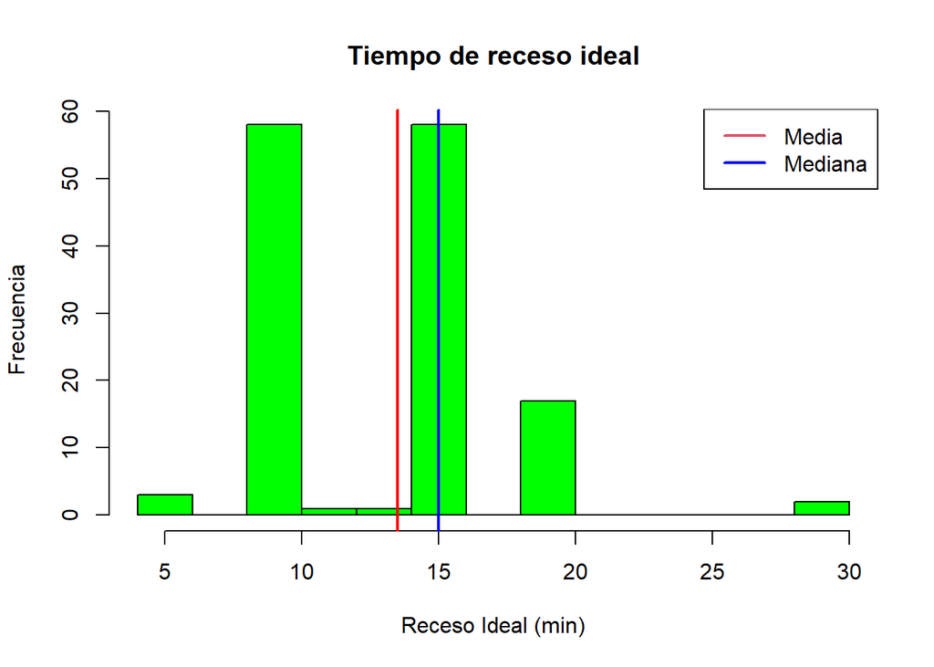

```r
hist(DFV$Receso_ideal, main="Tiempo de receso ideal", col="green", xlab="Receso Ideal (min)", ylab="Frecuencia")
abline(v=mean(DFV$Receso_ideal, na.rm=T),col="red",lwd=2)
abline(v=median(DFV$Receso_ideal, na.rm=T),col="blue",lwd=2)
legend(x = "topright", legend = c("Media", "Mediana"), lty= c(1,1,1), col=c(2,"blue"), lwd=2) # topright es la ubicación de la leyenda
```

*5.9.3. Análisis de la gráfica:*

Según el histograma “Tiempo de receso ideal” que es de tipo bimodal se indica que para la mayoría de estudiantes universitarios el tiempo de receso ideal varía de 9 a 10 minutos y de 14 a 15 minutos.

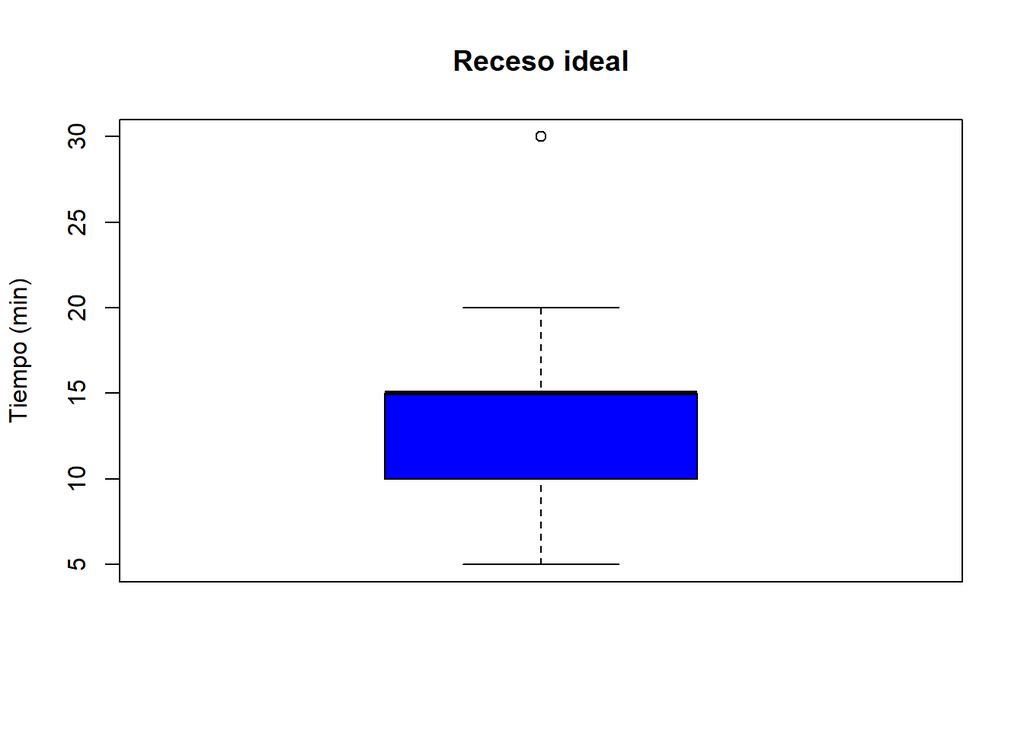

```r
boxplot(DFV$Receso_ideal, main="Receso ideal", col="blue", ylab= "Tiempo (min)")
```

*Fuente: https://thegeniusofplay.org/espanol/consejos/articulos/10-razones-por-las-que-los-chicos-deber%C3%ADan-tener-recreo-todos-los-d%C3%ADas.aspx#.YVkafZrMLIU*

*5.9.5. Intervalo de confianza*

```
##      [,1]      [,2]
## [1,] "lim_inf" "12.82"
## [2,] "lim_sup" "14.19"
```

*5.9.6. Análisis del intervalo de confianza*

En cuanto al receso ideal, tenemos que sus intervalos de confianza para la media cuyos extremos, inferior y superior,son 12.82 y 14.19 con un nivel de confianza del 95% y un nivel significativo del 5%. El margen de error es de 1.37, lo cual se obtuvo restando los limites obtenidos. Finalmente calculamos los valores críticos tomando la mitad del nivel significativo y el grado de libertad como parámetros.

**5.10. ¿Cuántos dispositivos tecnológicos usas?**

*5.10.1. Descriptor numérico* La moda de la variable Dispositivos_tecnologicos es:

```r
library(prettyR)
Mode(DFV$Dispositivos_tecnologicos)
```

```
## [1] "2"
```

La varianza de la variable Dispositivos_tecnologicos es:

```r
round(var(DFV$Dispositivos_tecnologicos, na.rm = TRUE), digits = 2)
```

```
## [1] 0.61
```

La desviación estándar de la variable Dispositivos_tecnologicos es:

```r
round(sd(DFV$Dispositivos_tecnologicos, na.rm = TRUE), digits = 2)
```

```
## [1] 0.78
```

Coeficiente de variación

```r
round(sd(DFV$Dispositivos_tecnologicos, na.rm=T), 2) -> d1
round(mean(DFV$Dispositivos_tecnologicos, na.rm=T), 2) -> p1
round(d1/p1, 2)  # Coeficiente de variación
```

```
## [1] 0.36
```

*5.10.2. Descriptor gráfico*

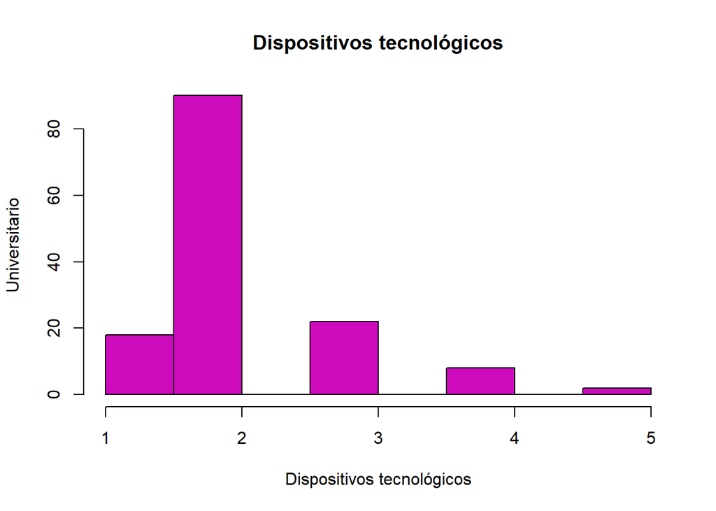

```r
hist(DFV$Dispositivos_tecnologicos, breaks= 10, col=c(6), main="Dispositivos tecnológicos", xlab="Dispositivos tecnológicos", ylab="Universitario")
```

*5.10.3. Análisis de la gráfica*

Examinando el gráfico de barras “Dispositivos tecnológicos” el cuál es de tipo unimodal donde la mayor frecuencia de las observaciones se encuentra en 2, indicándonos que la mayoría de estudiantes de nuestra muestra estadística cuenta con 2 dispositivos tecnológicos para el desarrollo de sus clases en línea. No obstante, un grupo reducido de estudiantes posee 5 dispositivos tecnológicos. Los resultados obtenidos son sustanciales porque nos permitirá evaluar la posibilidad de relación entre cantidad de dispositivos con promedio académico.

*5.10.4. Intervalo de confianza*

```
##      [,1]      [,2]
## [1,] "lim_inf" "2.05"
## [2,] "lim_sup" "2.32"
```

*5.10.5. Análisis del intervalo de confianza*

Analizando la variable Dispositivos_tecnologicos, en cuanto a la cantidad de dispositivos tecnológicos, tenemos que sus intervalos de confianza para la media cuyos extremos, inferior y superior,son 2.05 y 2.32 con un nivel de confianza del 95% y un nivel significativo del 5%. El margen de error es de 0.26, lo cual se obtuvo restando los limites obtenidos. Finalmente calculamos los valores críticos tomando la mitad del nivel significativo y el grado de libertad como parámetros.

*Bloque de docentes*

**5.11. ¿En qué universidad enseñas?**

*5.11.1. Descriptor gráfico*

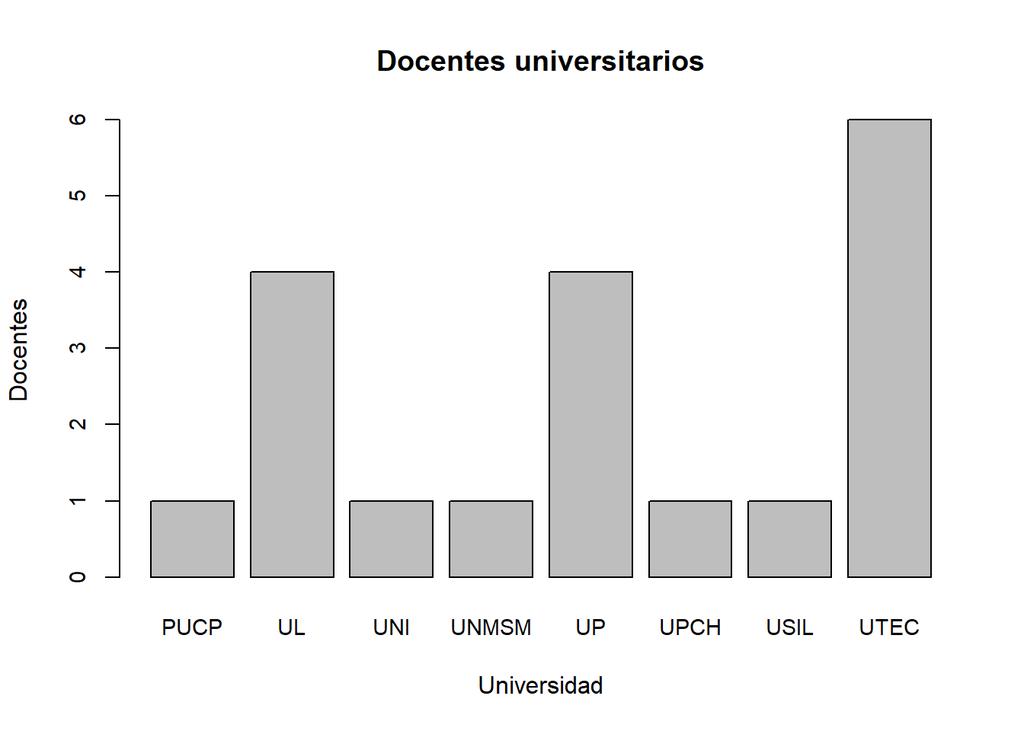

```r
barplot(table(DFV$Universidad_enseñanza), ylab= "Docentes", xlab="Universidad", main="Docentes universitarios", cex.axis=0.9, cex.names=0.9)
```

*5.11.2. Análisis del gráfico:*

El total de docentes encuestados ha incrementado en esta segunda entrega a un total de **19** . Además, como se puede observar en la gráfica “Docentes universitarios”, la universidad con mayor cantidad de encuestados es **UTEC** y las universidades con menor cantidad de encuestados son la **PUCP**, **UNI**, **UNMSM**, **UPCH** y la **USIL**.

```r
sum(table(DFV$Universidad_enseñanza))
```

```
## [1] 19
```

**5.12. ¿Cuántos cursos llevaste relacionado con técnicas didácticas de aprendizaje?**

```r
sum(table(DFV$Cantidad_cursos_didacticos))
```

```
## [1] 19
```

```r
round(sd(DFV$Cantidad_cursos_didacticos, na.rm=T), 2)
```

```
## [1] 2.74
```

El promedio de la variable “Cantidad_cursos_didacticos” es:

```r
round(mean(DFV$Cantidad_cursos_didacticos, na.rm=T), 2)
```

```
## [1] 5.53
```

```r
library(prettyR)
round(mean(DFV$Cantidad_cursos_didacticos, na.rm=T), 2)
```

```
## [1] 5.53
```

La mediana de la variable “Cantidad_cursos_didacticos”es:

```r
library(prettyR)
round(median(DFV$Cantidad_cursos_didacticos, na.rm=T), 2)
```

```
## [1] 6
```

Coeficiente de variación de la variable “Cantidad_cursos_didacticos”:

```r
round(sd(DFV$Cantidad_cursos_didacticos, na.rm=T), 2) -> d1
round(mean(DFV$Cantidad_cursos_didacticos, na.rm=T), 2) -> p1
round(d1/p1, 2)  # Coeficiente de variación
```

```
## [1] 0.5
```

*5.12.2. Descriptor gráfico:*

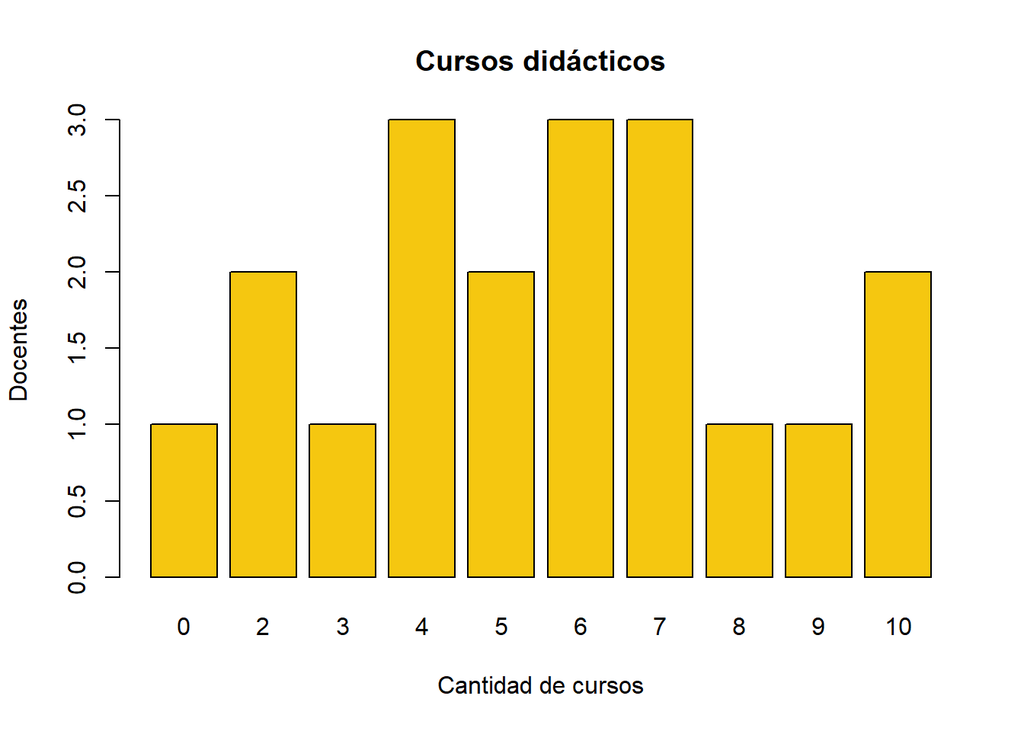

```r
barplot(table(DFV$Cantidad_cursos_didacticos), main="Cursos didácticos", xlab="Cantidad de cursos", ylab="Docentes", col=c(7))
```

*5.12.3. Análisis:*

El gráfico de “Cursos didácticos” es trimodal, caracterizado por la presencia de tres modas que indican que la mayoría de docentes universitarios ha llevado entre 4, 6 y 7 cursos didácticos. La significación de estos resultados consisten en la relación que guarda a que los docentes hallan llevado cursos didácticos y el uso de las herramientas digitales usadas como ayuda para mejorar el procesamiento de la enseñanza dada en el entorno virtual dónde es fundamental que el docente dominen las TICs, ya que, esto les permitirá facilitarle a los estudiantes el acceso a la información y a su vez garantizar el aprendizaje didáctico.

**5.13. ¿Cuántas horas académicas en total llevaste o estás llevando en cursos relacionados a técnicas didácticas de aprendizaje?**

*5.13.1. Descriptor numérico:* La desviación estándar de la variable “Horas_curso_docente” es:

```r
round(sd(DFV$Horas_curso_docente, na.rm=T), 2)
```

```
## [1] 41.49
```

El promedio de la variable “Horas_curso_docente” es:

```r
round(mean(DFV$Horas_curso_docente, na.rm=T), 2)
```

```
## [1] 53.95
```

```r
library(prettyR)
round(mean(DFV$Horas_curso_docente, na.rm=T), 2)
```

```
## [1] 53.95
```

La mediana de la variable Horas_curso_docente es:

```r
library(prettyR)
round(median(DFV$Horas_curso_docente, na.rm=T), 2)
```

```
## [1] 40
```

```r
round(sd(DFV$Horas_curso_docente, na.rm=T), 2) -> d1
round(mean(DFV$Horas_curso_docente, na.rm=T), 2) -> p1
round(d1/p1, 2)  # Coeficiente de variación
```

```
## [1] 0.77
```

*5.13.2. Descriptor gráfico:*

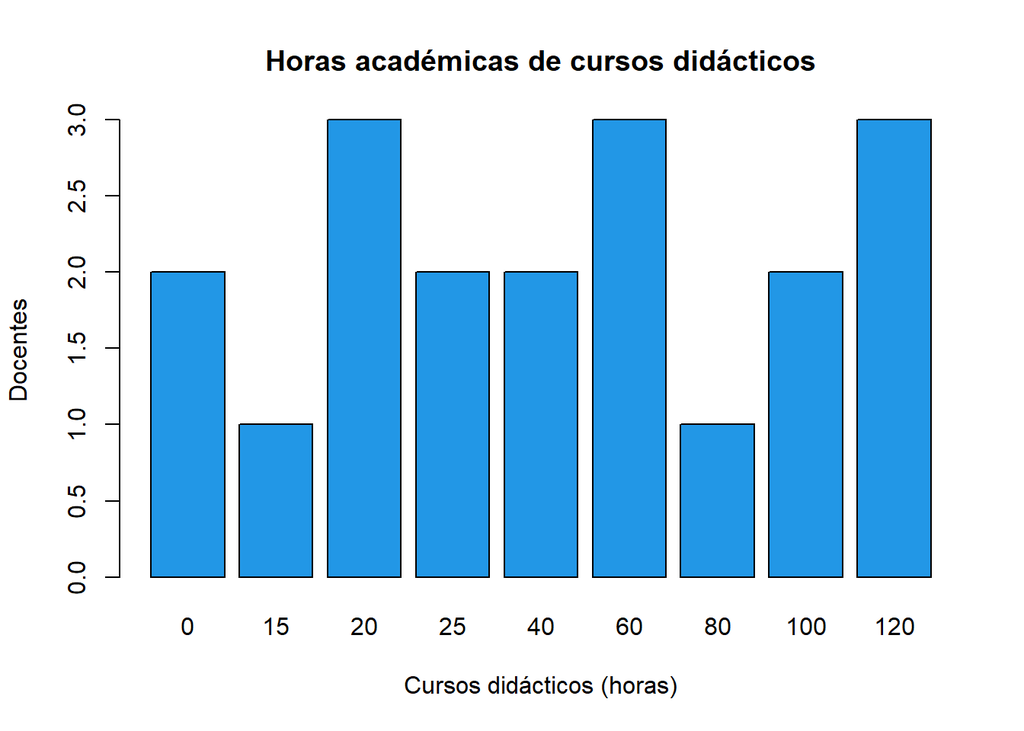

```r
barplot(table(DFV$Horas_curso_docente), main="Horas académicas de cursos didácticos", xlab="Cursos didácticos (horas)", col=c(12), ylab= "Docentes")
```

*5.13.3. Análisis del gráfico:*

*5.13.4. Intervalo de confianza:*

```
##      [,1]      [,2]
## [1,] "lim_inf" "33.95"
## [2,] "lim_sup" "73.94"
```

*5.13.5. Análisis del intervalo de confianza:*

Analizando la variable Horas_curso_docente, en cuanto a la cantidad de horas de cursos didácticos, tenemos que sus intervalos de confianza para la media cuyos extremos, inferior y superior,son 33.95 a 73.94 con un nivel de confianza del 95% y un nivel significativo del 5%. El margen de error es de 39.99, lo cual se obtuvo restando los limites obtenidos. Finalmente calculamos los valores críticos tomando la mitad del nivel significativo y el grado de libertad como parámetros.

**5.14. ¿Cuántas horas llevaste en este tipo de cursos de competencias digitales?**

*5.14.1. Descriptor numérico:*

La desviación estándar de la variable es:

```r
round(sd(DFV$Horas_competencias_digitales, na.rm=T), 2)
```

```
## [1] 64.81
```

El promedio de la variable es:

```r
round(mean(DFV$Horas_competencias_digitales, na.rm=T), 2)
```

```
## [1] 173.16
```

```r
round(sd(DFV$Horas_competencias_digitales, na.rm=T), 2) -> d1
round(mean(DFV$Horas_competencias_digitales, na.rm=T), 2) -> p1
round(d1/p1, 2)  # Coeficiente de variación
```

```
## [1] 0.37
```

*5.14.2. Descriptor gráfico*

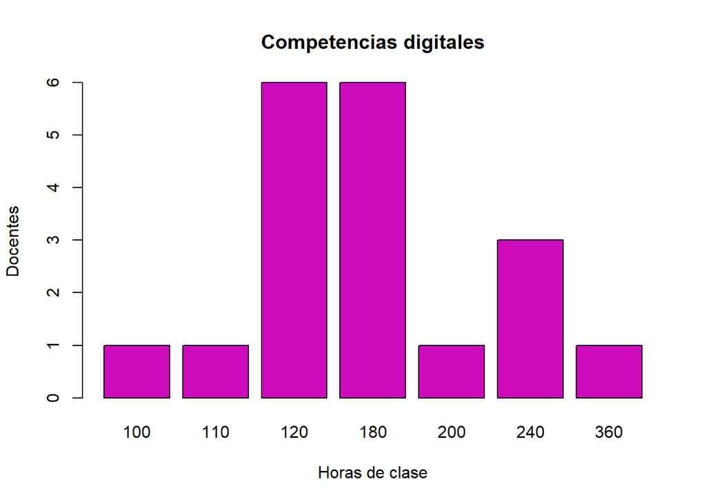

```r
barplot(table(DFV$Horas_competencias_digitales), main="Competencias digitales", xlab="Horas de clase", col=c(6), ylab= "Docentes")
```

*5.14.3. Análisis del gráfico:*

En el gráfico de “Competencias digitales” nos indica que la gran mayoría de los encuestados pertenecientes al grupo de los docentes llevó entre 120 a 180 horas, siendo estos los valores máximos. Asimismo se puede decir que las horas mínimas que han llevado los docentes en cursos de competencias digitales están entre 100, 110, 200 y 360.

*5.14.4. Intervalo de confianza:*

[output not shown]

*5.14.5. Análisis del intervalo de confianza:*

**5.15. ¿Cuánto tiempo tienes enseñando a nivel universitario?**

*5.15.1. Descriptor numérico:*

La desviación estándar de la variable Tiempo_enseñanza es:

```r
round(sd(DFV$Tiempo_enseñanza, na.rm=T), 2)
```

```
## [1] 5.41
```

El promedio de la variable “Tiempo_enseñanza es:

```r
round(mean(DFV$Tiempo_enseñanza, na.rm=T), 2)
```

```
## [1] 13
```

```r
round(sd(DFV$Tiempo_enseñanza, na.rm=T), 2) -> d1
round(mean(DFV$Tiempo_enseñanza, na.rm=T), 2) -> p1
round(d1/p1, 2)  # Coeficiente de variación
```

```
## [1] 0.42
```

*5.15.2. Descriptor gráfico:*

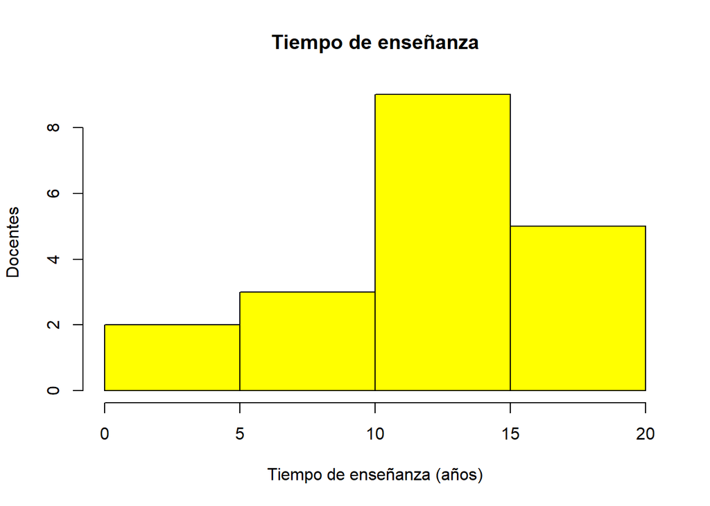

```r
hist(DFV$Tiempo_enseñanza, type="p", col="yellow", xlab= "Tiempo de enseñanza (años)", ylab="Docentes", main= "Tiempo de enseñanza")
```

*5.15.3. Análisis del gráfico:*

En el gráfico “tiempo de enseñanza” se observa que la gran mayoría de docentes en la muestra tiene de 10 a 15 años de experiencia brindando enseñanza a estudiantes universitarios. Esto nos ayuda a saber la relación e importancia que tiene el tiempo de enseñanza con la capacidad de utilizar las mejores estrategias de enseñanza para lograr el óptimo aprendizaje de los estudiantes.

*5.15.4. Intervalo de confianza:*

```
##      [,1]      [,2]
## [1,] "lim_inf" "10.39"
## [2,] "lim_sup" "15.61"
```

*5.15.5. Análisis del intervalo de confianza:*

**5.16. Receso y Receso ideal**

*5.16.1. Descriptor numérico*

La desviación estándar de la variable “Receso y Receso ideal” es:

```r
round(sd(DFV$Receso, na.rm=T), 2)
```

```
## [1] 3.84
```

El promedio de la variable “Receso” es:

```r
round(mean(DFV$Receso, na.rm=T), 2)
```

```
## [1] 9.54
```

*5.16.2. Descriptor gráfico*

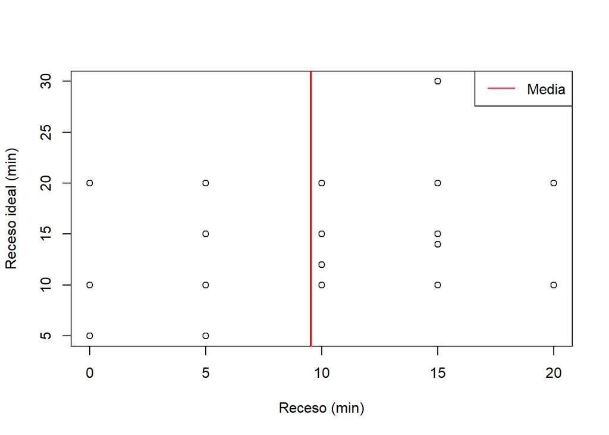

```r
plot(DFV$Receso, DFV$Receso_ideal, xlab="Receso (min)", ylab="Receso ideal (min)")
abline(v=mean(DFV$Receso, na.rm=T),col="red",lwd=2)
legend(x = "topright", legend = c("Media"), lty= c(1), col=c(2), lwd=2) # topright es la ubicación de la leyenda
```

*5.16.3. Análisis del gráfico*

La media de estas mediciones es **9.54**, como se indica en la gráfica de puntos. Las distancias entre cada punto (medición) y la media ayudarán a medir la variabilidad. Si las distancias son grandes, los datos son más dispersos o variables que si las distancias son pequeñas. Las mediciones a la derecha producen desviaciones positivas y a la izquierda producen desviaciones negativas. En este caso podemos observar que existe más mediciones a la derecha del promedio, es decir que hay más desviaciones positivas. Asimismo, se puede observar que al ser la desviación estándar relativamente grande los datos son muy variables.

## Segunda parte

#### **6. Modelos de las variables aleatorias**

Ahora presentaremos el planteamiento e identificación de los parámetros de nuestras variables de interés.

[output not shown]

*6.1. Justificación con gráficas*

1. Promedio_académico

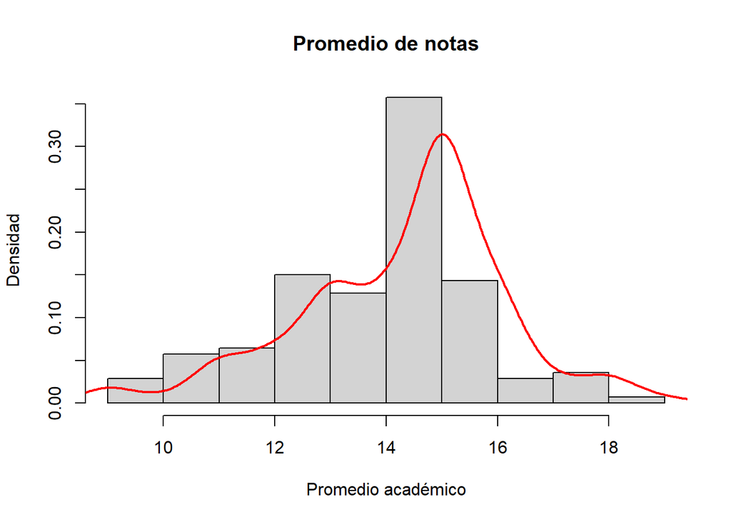

```
##
##  Shapiro-Wilk normality test
##
## data:  DFV$Promedio_academico
## W = 0.93776, p-value = 7.16e-06
```

```
## [1] 14.32143
```

```
## [1] 1.851571
```

```
##
##  One-sample Kolmogorov-Smirnov test
##
## data:  DFV$Promedio_academico
## D = 0.43817, p-value < 2.2e-16
## alternative hypothesis: two-sided
```

La prueba de Hipótesis es:

H0: Los datos de promedio académico se ajustan a la distribución Normal

H1: Los datos de horas promedio académico NO se ajustan a la distribución Normal

La prueba de K-S resulta significativa, es decir, Los datos de promedio académico NO se ajustan a la distribución Normal

2. Cantidad_cursos_didacticos:

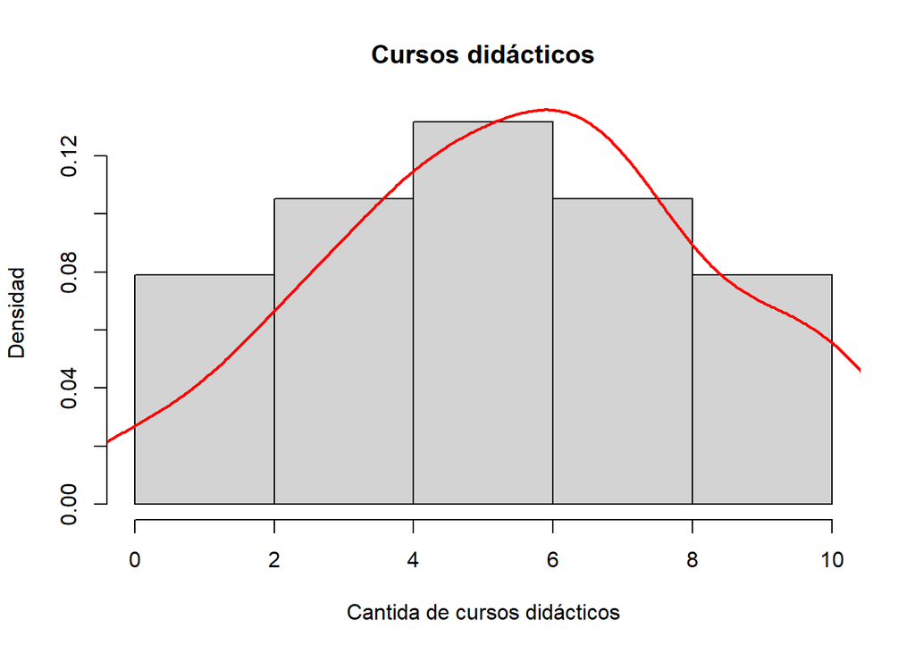

```
##
##  Shapiro-Wilk normality test
##
## data:  DFV$Cantidad_cursos_didacticos
## W = 0.97464, p-value = 0.8639
```

```
## [1] 5.526316
```

```
## [1] 2.735942
```

```
##
##  One-sample Kolmogorov-Smirnov test
##
## data:  DFV$Cantidad_cursos_didacticos
## D = 1, p-value < 2.2e-16
## alternative hypothesis: two-sided
```

3. Horas_competencias_digitales:

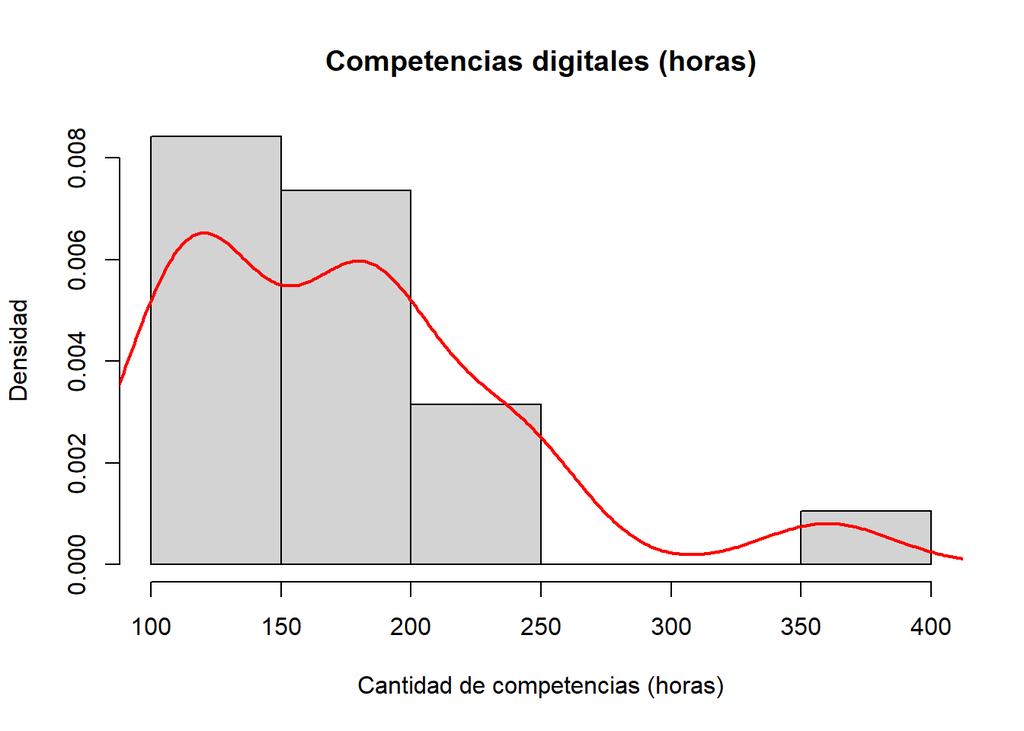

```
## [1] 173.1579
```

```
## [1] 64.81192
```

```
##
##  One-sample Kolmogorov-Smirnov test
##
## data:  DFV$Horas_competencias_digitales
## D = 0.21593, p-value = 0.3384
## alternative hypothesis: two-sided
```

La prueba de Hipótesis es:

H0: Los datos de horas de competencias digitales se ajustan a la distribución Gamma

H1: Los datos de horas de competencias digitales NO se ajustan a la distribución Gamma

La prueba de K-S resulta no significativa, es decir, Los datos de horas de competencias digitales se ajustan a la distribución Gamma.

#### **7. Preguntas e hipótesis de nuestro estudio estadístico**

A partir de las preguntas planteadas, cuyo objeto de estudio es la relación de dos variables, se pueden establecer las posibles hipótesis para cada caso estudiado. Para posteriormente pode determinar la existencia de posibles patrones dentro de nuestra investigación que alude al acceso a una educación virtual de calidad aplicado al uso de técnicas didácticas en las universidades de Lima Metropolitana - Perú.

En primer lugar, analizaremos las observaciones de los universitarios.

```r
library(ggplot2)
library(gcookbook)
```

**7.1. Primera pregunta** **¿La media del tiempo de receso que recibe el estudiante se aproxima a la media de receso ideal que solicitan los alumnos?**

*7.1.1. Descriptor numérico:*

```r
temp1 <- DFV[!is.na(DFV$`Receso`), ]
temp2 <- DFV[!is.na(DFV$`Receso_ideal`), ]
rec_real <- temp1$`Receso`
rec_ideal <- temp2$`Receso_ideal`
```

Este es el promedio de el tiempo de receso que los docentes le brindan a sus alumnos:

```r
a <- round(mean(rec_real), digit = 2)
a
```

```
## [1] 9.54
```

Este es el promedio del tiempo de receso que los alumnos esperan tener:

```r
b <- round(mean(rec_ideal), digit = 2)
b
```

```
## [1] 13.51
```

Observando los promedios obtenidos, podemos darnos cuenta que la diferencia no es muy grande y es solo de:

```r
abs(a-b)
```

```
## [1] 3.97
```

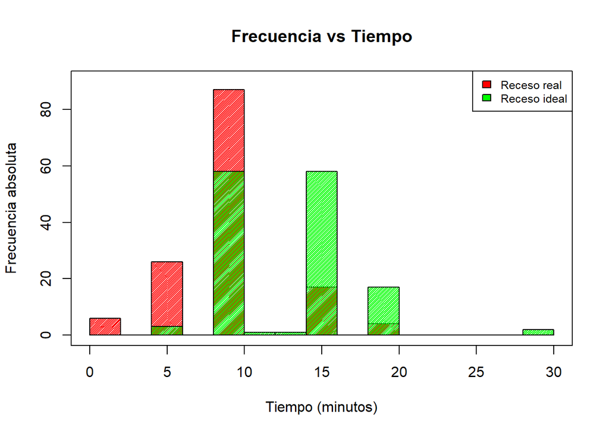

```r
plot(0,0,type="n",xlim=c(0, 30),ylim=c(0, 90),xlab = "Tiempo (minutos)",ylab="Frecuencia absoluta",main = "Frecuencia vs Tiempo")
plot(hist(rec_real, plot = FALSE),col="red",density = 65,add=TRUE)
plot(hist(rec_ideal, plot = FALSE),col="green",density = 60,add=TRUE)
legend("topright",c("Receso real","Receso ideal"), fill = c("red","green"), cex = 0.77)
```

*7.1.2. Análisis del gráfico:*

En el gráfico Frecuencia vs Tiempo, es valido decir que el tiempo de receso ideal se encuentra dentro del receso real, y que a la vez no son muy simétricos, viendo que existe poco encuentro entre ambos casos, cuya diferencia no es mínima, hablando así de una proporción un poco menor a la mediana de esta frecuencia.

*7.1.3. Descriptor gráfico:*

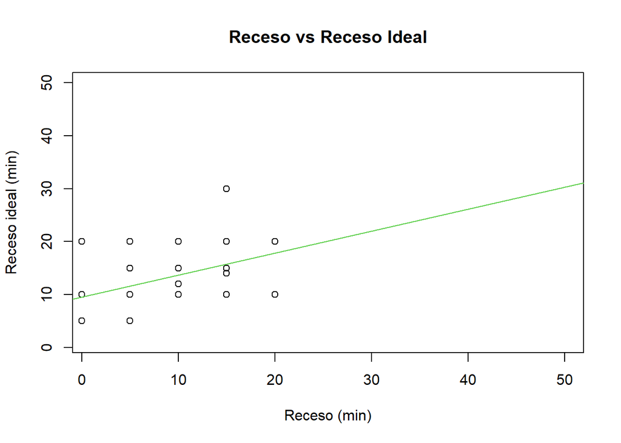

```r
plot(DFV$Receso,DFV$Receso_ideal, main = "Receso vs Receso Ideal",xlab = "Receso (min)",ylab = "Receso ideal (min)", xlim=c(1,50), ylim=c(1,50))
abline(lm(DFV$Receso_ideal~DFV$Receso), col=3)  # regresion line
```

```r
table(DFV[DFV$Soy == "Universitario",]$Receso,DFV[DFV$Soy == "Universitario",]$Receso_ideal)
```

```
##
##       5 10 12 14 15 20 30
##   0   1  4  0  0  0  1  0
##   5   2 12  0  0 10  2  0
##   10  0 40  1  0 40  6  0
##   15  0  1  0  1  8  5  2
##   20  0  1  0  0  0  3  0
```

*7.1.4. Análisis del gráfico:*

En el diagrama de dispersión “Receso ideal vs Receso” se puede denotar la existencia de una relación lineal positiva entre la variable “receso” y “receso ideal”. En cuanto a la fuerza de la relación podemos afirmar que es débil puesto que se observa el poco ajuste entre los datos con respecto al modelo lineal de regresión.

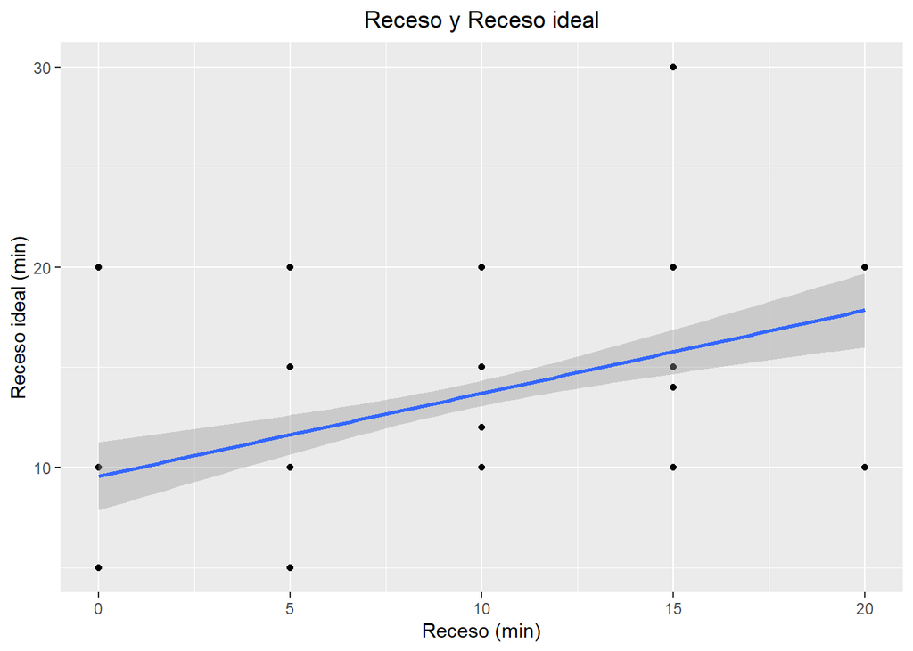

```r
ggplot(DFV, aes(x=Receso, y=Receso_ideal)) + geom_point()+ stat_smooth(method=lm)+ ggtitle("Receso y Receso ideal")+theme(plot.title = element_text(hjust = 0.5)) + xlab("Receso (min)") + ylab("Receso ideal (min)")
```

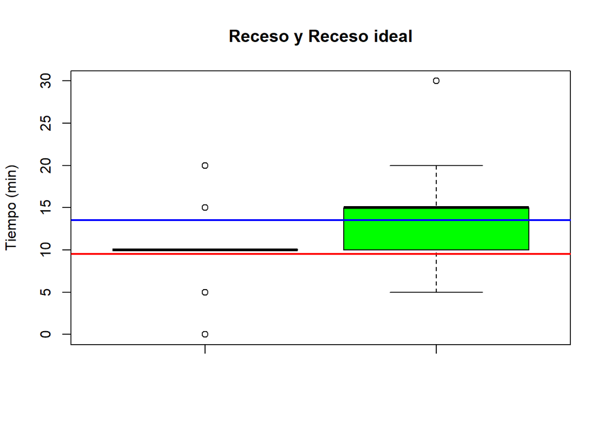

```r
boxplot(DFV$Receso,DFV$Receso_ideal, col=(c("gold", "green")), ylab="Tiempo (min)", main="Receso y Receso ideal")
abline(h=mean(DFV$Receso, na.rm=T), col="red",lwd=2)
abline(h=mean(DFV$Receso_ideal, na.rm=T), col="blue",lwd=2)
legend(1.1,80,legend=c("media de 1", "media de 2"),col=c("red", "blue"),lwd=2)
```

*7.1.5. Análisis de los dos gráficos:*

*7.1.6. Primera hipótesis:*

Por lo general, el tiempo de receso dado por los docentes a sus alumnos, no suele coincidir con el receso ideal que ellos consideran necesario para tener una buena concentración en una clase de 2 horas.

**7.2. Segunda pregunta** **¿Cuál es la universidad que presenta mayor frecuencia de observaciones en el estudio estadístico realizado?**

*7.2.1. Descriptor numérico:*

```r
temp1 <- DFV[!is.na(DFV$`Universidad`), ]
temp2 <- DFV[!is.na(DFV$`Universidad_enseñanza`), ]
uni_estudia <- temp1$`Universidad`
uni_ensena <- temp2$`Universidad_enseñanza`
table(uni_estudia)
```

```
## uni_estudia
## Otros  PUCP    UL   UNI UNMSM    UP   UPC  UPCH  UTEC   UTP
##    16     2     9     1     2     7     5     2    88     8
```

```r
table(uni_ensena)
```

```
## uni_ensena
##  PUCP    UL   UNI UNMSM    UP  UPCH  USIL  UTEC
##     1     4     1     1     4     1     1     6
```

```r
cat("Moda de los estudiantes encuestados: ", mode(uni_estudia), "\n")
```

[output not shown]

```r
cat("Moda de los docentes encuestados: ", mode(uni_ensena), "\n")
```

[output not shown]

*7.2.2. Descriptor gráfico:*

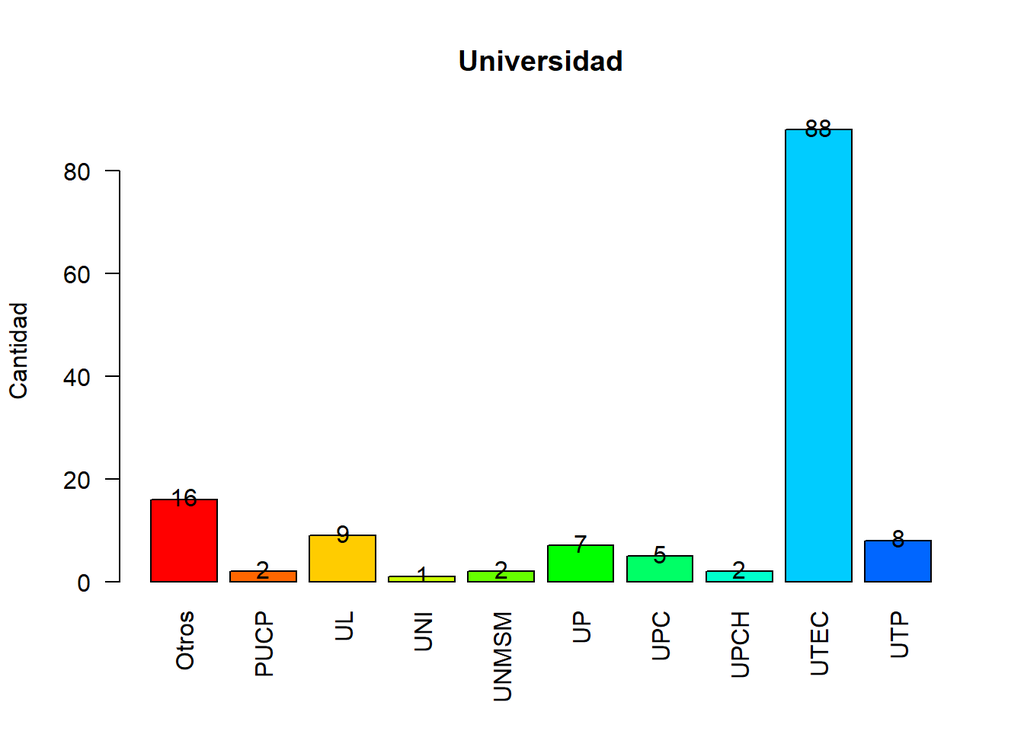

```r
A <-barplot(table(DFV$Universidad), col=rainbow(15), main = "Universidad", ylab = "Cantidad", ylim=c(0,90), las=2)
text(A, table(DFV$Universidad) + 0.5, labels = table(DFV$Universidad))
```

*7.2.3. Análisis del gráfico:*

En el gráfico de barras “Universidad” se clasifica como unimodal, siendo la universidad UTEC, la cual presenta una mayor frecuencia de observaciones. No obstante, las universidades con menor participación son UNMSM, UNI, PUCP, UPCH.

*7.2.4. Segunda hipótesis:*

**7.3. Tercera pregunta**

¿Cual es la universidad que presenta mayor rendimiento académico sobre el resto de las universidades perteneciente a la población de estudio?

*7.3.1. Descriptor gráfico:*

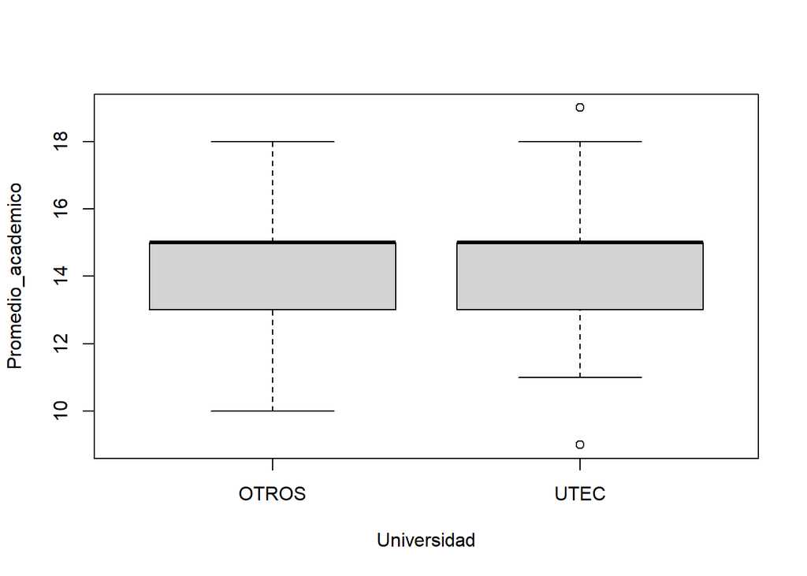

```r
univ=ifelse(DFV$Universidad=="UTEC","UTEC","OTROS")
boxplot(DFV$Promedio_academico~univ, xlab="Universidad", ylab="Promedio_academico")
```

*7.3.2. Análisis de la gráfica:*

*7.3.3. Tercera hipótesis:*

Los estudiantes de UTEC presentan un mayor rendimiento académico que el resto de las universidades.

**7.4.Cuarta pregunta:** **¿Dependerá el desempeño académico del sexo del estudiante?**

*7.4.1. Descriptor gráfico*

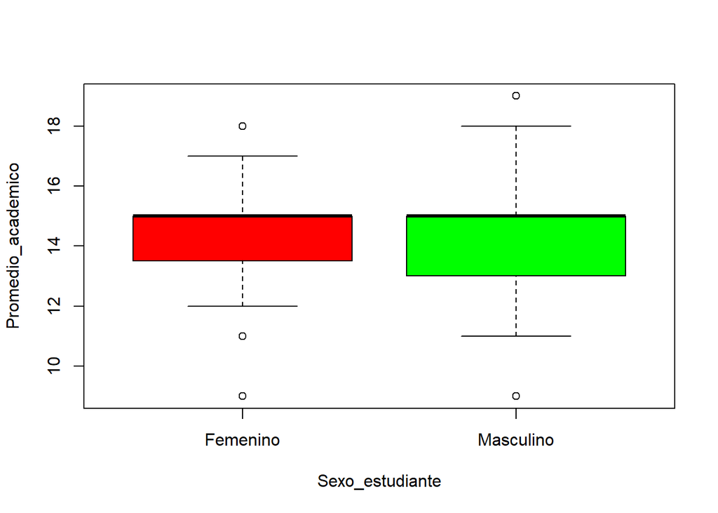

```r
boxplot(DFV$Promedio_academico[DFV$Universidad=="UTEC"]~
          DFV$Sexo_estudiante[DFV$Universidad=="UTEC"], xlab="Sexo_estudiante", ylab="Promedio_academico", col=rainbow(ncol(trees)))
```

*7.4.2. Análisis del gráfico:*

En el diagrama de cajas “Sexo_estudiante” se puede observar la presencia de 5 supuestos valores atípicos, 3 y 2 por parte de estudiantes encuestados con sexo femenino y masculino respectivamente, los cuales se consideraran en nuestro estudio estadifico descriptivo, ya que son valores que nos brindan y formación. Lo que en efecto modifica la consideración de valores máximos y mínimos que surgen a partir de la visualización de dicho diagrama de cajas. Posteriormente, se puede observar que existe una ligera simetría en ambos gráficos de estudio. Otro punto notable es la ubicación del valor de la mediana en ambos gráficos, teniendo una misma ubicación.

*7.4.3.Cuarta hipótesis:*

El desempeño académico de los varones es similar al de las mujeres. Mediante esta hipótesis se demostrará la igualdad de habilidades intelectuales según género.

```r
t.test(DFV$Promedio_academico[DFV$Universidad=="UTEC"]~
          DFV$Sexo_estudiante[DFV$Universidad=="UTEC"])
```

```
##
##  Welch Two Sample t-test
##
## data:  DFV$Promedio_academico[DFV$Universidad == "UTEC"] by DFV$Sexo_estudiante[DFV$Universidad == "UTEC"]
## t = -0.05338, df = 84.177, p-value = 0.9576
## alternative hypothesis: true difference in means between group Femenino and group Masculino is not equal to 0
## 95 percent confidence interval:
##  -0.8693859  0.8239313
## sample estimates:
##  mean in group Femenino mean in group Masculino
##                14.25000                14.27273
```

**7.5. Quinta pregunta** **A partir del promedio de las notas obtenidas ¿Cuál es la nota promedio de los estudiantes?**